# PART 1- DATA UNDERSTANDING & EDA

# Fraudulent Transactions Prediction

### Aiming at detecting fraud transactions and helps to create machine learning model to predict fraud.

[figure not shown]

# Business Understanding

## FRAUDULENT TRANSACTIONS & BUSINESS UNDERSTANDING

#### What is Payment Fraud?

Payment fraud is any type of false or illegal transaction completed by a cybercriminal. The perpetrator deprives the victim of funds, personal property, interest, or sensitive information via the Internet. Ecommerce businesses rely on electronic transactions to charge customers for products and services. The increased volume of electronic transactions has also resulted in an increase in fraudulent activities.

#### Types of fraud:-

1. Business credit card fraud
2. Wire fraud
3. ACH fraud
4. Forgery
5. Invoice fraud
6. Phishing
7. Identity theft
8. Pagejacking
9. Merchant identity fraud

| 1. Business credit card fraud (B2C) | If you issue business credit cards, you need to ensure every employee takes necessary precautions to appropriately protect and use them. The key is to set strict policies about what does and doesn't q… |
| --- | --- |
| 2. Wire fraud | Another common type of fraud is illegal wire transfers. Criminals try to trick individuals into authorizing a wire transfer from a small-business bank account. They may pose as a customer or vendor to… |
| 3. ACH fraud | Small businesses often use automated clearing house, or ACH, transfers. These can be a convenient way to pay bills and direct deposit an employee's salary. Unfortunately, they also can open up opportu… |
| 4. Forgery | Many of today's transactions are digital, but forgery can still happen. With this type of fraud, someone obtains a company check, makes it out to themselves or an accomplice, and forges the authorized… |
| 5. Invoice fraud | Finally, invoice fraud is another common scheme that can happen to small business owners. Criminals send false invoices that, at first look, appear to be legitimate charges from vendors for products o… |
| 6. Phishing | Any emails or websites that require personal or private information such as credit card, bank account or login credentials are prone to phishing. If the source is trusted, such as a partner with a ban… |
| 7. Identity theft | Identity theft exists outside of the digital realm as well, but it's a common type of fraud online. A cybercriminal who steals personal information and uses it under false pretense is engaging in iden… |
| 8. Pagejacking | Hackers can reroute traffic from your ecommerce site by hijacking part of it and directing visitors to a different website. The unwanted site may contain potentially malicious material that hackers us… |
| 9. Merchant identity fraud | This method involves criminals setting up a merchant account on behalf of a seemingly legitimate business and charging stolen credit cards. The hackers then vanish before the cardholders discover the … |

[figure not shown]

#### How does fraud happen?

Hackers often pose as a legitimate representative and contact credit card owners asking for sensitive information, then use the following means of interaction to steal personal data:

```
- Email
- Texting malware to smartphones
- Instant messaging
- Rerouting traffic to fraudulent websites
- Phone calls
- Online auctions
```

#### How can e-commerce businesses mitigate fraud?

While it's challenging to entirely eliminate the threat of fraud for eCommerce stores, you can help protect against it by continually updating your network security systems. There are a number of other ways to protect your business against fraudulent payments:

```
1. Maintain awareness of the latest fraud trends
2. Partner with a verified payment processor
3. Encrypt transactions and emails containing confidential information
4. Ensure that tokens and login credentials are regularly changed
5. Establish a policy regarding access to confidential information
6. Constantly run security checks with antivirus software
7. Require customers to log in to an individual account prior to making a purchase
```

[figure not shown]

#### What is fraudulent transactions?

A fraudulent transaction is the unauthorized use of an individual’s accounts or payment information. Fraudulent transactions can result in the victim’s loss of funds, personal property, or personal information.

The fraudulent transaction is one of the most serious threats to online security nowadays. Artificial Intelligence is vital for financial risk control in the cloud environment. Many studies attempted to explore methods for online transaction fraud detection; however, the existing methods are insufficient to conduct detection with high precision.

Fraud prevention is the implementation of a strategy to detect fraudulent transactions or banking actions and prevent these actions from causing financial damage and the reputation of the client and the financial institution.

There are always financial frauds and They can happen in virtual and physical ways. So the investment in security has been increasing. Keep your business safe from online payment fraud There is no guaranteed method for payment fraud prevention. By taking certain precautions, however, you can minimize the damage they cause and make sure your business has the best chance to thrive despite them.

[figure not shown]

# Synthetic Dataset

The dataset provided to us is synthetic dataset.

Synthetic data is information that's artificially manufactured rather than generated by real-world events. Synthetic data is created algorithmically, and it is used as a stand-in for test datasets of production or operational data, to validate mathematical models and, increasingly, to train machine learning models.

Synthetic data does not contain any personal information, it is a sample data that has a similar distribution with original data. Though the utility of synthetic data can be lower than real data in some cases, there are also cases where synthetic data is almost as valuable as real data. For instance, a team at Deloitte Consulting generated 80% of the training data for a machine learning model by synthesizing data. The resulting model accuracy was similar to a model trained on real data.

Especially when companies need data to train machine learning algorithms and their training data is highly imbalanced (e.g. more than 99% instances belong to one class), synthetic data generation can help build accurate machine learning models.

### What are the techniques of synthetic data generation?

**Generating according to distribution**

For cases where real data does not exist but data analyst has a comprehensive understanding of how dataset distribution would look like, the analyst can generate a random sample of any distribution such as Normal, Exponential, Chi-square, t, lognormal and Uniform. In this technique, the utility of synthetic data varies depending on the analyst’s degree of knowledge about a specific data environment.

**Fitting real data to a known distribution**

If there is a real-data, then businesses can generate synthetic data by determining the best fit distributions for given real-data. If businesses want to fit real-data into a known distribution and they know the distribution parameters, businesses can use Monte Carlo method to generate synthetic data.

[figure not shown]

# Business Problem

### BUSINESS PROBLEM- FRAUD TRANSACTIONS CLASSIFICATION

We will build a classifier for predicting fraud transactions.

## Lets Discuss on the Feature Given to us:

| **step** | maps a unit of time in the real world. In this case 1 step is 1 hour of time. Total steps 744 (30 days simulation). |
| --- | --- |
| **type** | CASH-IN, CASH-OUT, DEBIT, PAYMENT and TRANSFER. |
| **amount** | amount of the transaction in local currency. |
| **nameOrig** | customer who started the transaction |
| **oldbalanceOrg** | initial balance before the transaction |
| **newbalanceOrig** | new balance after the transaction |
| **nameDest** | customer who is the recipient of the transaction |
| **oldbalanceDest** | initial balance recipient before the transaction. Note that there is not information for customers that start with M (Merchants). |
| **newbalanceDest** | new balance recipient after the transaction. Note that there is not information for customers that start with M (Merchants). |
| **isFraud** | This is the transactions made by the fraudulent agents inside the simulation. In this specific dataset the fraudulent behavior of the agents aims to profit by taking control or customers accounts and … |
| **isFlaggedFraud** | The business model aims to control massive transfers from one account to another and flags illegal attempts. An illegal attempt in this dataset is an attempt to transfer more than 200.000 in a single … |

# Business Objective

**Objective: objective: To develop a model to predict whether a transaction is fraudulent or not. To predict feature importance which can help in predicting fraud more easily. Our main goal is to minimize the fraud and derive the best accuracy model with less log loss value.**

# Data Understanding

## Import Libraries

```python
# Handle table-like data and matrices
import pandas as pd
import numpy as np
from numpy import percentile
from datetime import date
import datetime
from datetime import timedelta
import scipy.stats as stats
import seaborn as sns
from scipy import stats
import re
from pandas_profiling import ProfileReport
from random import randint
import math

#For Feature Selection
from sklearn import feature_selection as fs
from sklearn.model_selection import cross_val_score
import sklearn.metrics as metrics
import io
import requests
from sklearn.tree import DecisionTreeClassifier

# Visualisation
import matplotlib.pyplot as plt
import seaborn as sns
import cufflinks as cf
import plotly
import plotly.express as px
from plotly import __version__
from plotly.offline import download_plotlyjs, init_notebook_mode, plot, iplot
init_notebook_mode(connected = True)
cf.go_offline()
import plotly.graph_objects as go
from plotly.subplots import make_subplots
import plotly.figure_factory as ff

# Modelling Algorithms
from sklearn.tree import DecisionTreeRegressor

# Configure visualisations
%matplotlib inline
%config InlineBackend.figure_format = 'retina'
plt.style.use("ggplot")
```

# Load Data

```python
dataset= pd.read_csv('Fraud.csv')
dataset
```

|  | step | type | amount | nameOrig | oldbalanceOrg | newbalanceOrig | nameDest | oldbalanceDest | newbalanceDest | isFraud | isFlaggedFraud |
| --- | --- | --- | --- | --- | --- | --- | --- | --- | --- | --- | --- |
| 0 | 1 | PAYMENT | 9839.64 | C1231006815 | 170136.00 | 160296.36 | M1979787155 | 0.00 | 0.00 | 0 | 0 |
| 1 | 1 | PAYMENT | 1864.28 | C1666544295 | 21249.00 | 19384.72 | M2044282225 | 0.00 | 0.00 | 0 | 0 |
| 2 | 1 | TRANSFER | 181.00 | C1305486145 | 181.00 | 0.00 | C553264065 | 0.00 | 0.00 | 1 | 0 |
| 3 | 1 | CASH_OUT | 181.00 | C840083671 | 181.00 | 0.00 | C38997010 | 21182.00 | 0.00 | 1 | 0 |
| 4 | 1 | PAYMENT | 11668.14 | C2048537720 | 41554.00 | 29885.86 | M1230701703 | 0.00 | 0.00 | 0 | 0 |
| ... | ... | ... | ... | ... | ... | ... | ... | ... | ... | ... | ... |
| 6362615 | 743 | CASH_OUT | 339682.13 | C786484425 | 339682.13 | 0.00 | C776919290 | 0.00 | 339682.13 | 1 | 0 |
| 6362616 | 743 | TRANSFER | 6311409.28 | C1529008245 | 6311409.28 | 0.00 | C1881841831 | 0.00 | 0.00 | 1 | 0 |
| 6362617 | 743 | CASH_OUT | 6311409.28 | C1162922333 | 6311409.28 | 0.00 | C1365125890 | 68488.84 | 6379898.11 | 1 | 0 |
| 6362618 | 743 | TRANSFER | 850002.52 | C1685995037 | 850002.52 | 0.00 | C2080388513 | 0.00 | 0.00 | 1 | 0 |
| 6362619 | 743 | CASH_OUT | 850002.52 | C1280323807 | 850002.52 | 0.00 | C873221189 | 6510099.11 | 7360101.63 | 1 | 0 |

6362620 rows × 11 columns

# Data Acquisition & Description (Statistical summaries and visualisations)

```python
dataset.info()
```

```
<class 'pandas.core.frame.DataFrame'>
RangeIndex: 6362620 entries, 0 to 6362619
Data columns (total 11 columns):
 #   Column          Dtype
---  ------          -----
 0   step            int64
 1   type            object
 2   amount          float64
 3   nameOrig        object
 4   oldbalanceOrg   float64
 5   newbalanceOrig  float64
 6   nameDest        object
 7   oldbalanceDest  float64
 8   newbalanceDest  float64
 9   isFraud         int64
 10  isFlaggedFraud  int64
dtypes: float64(5), int64(3), object(3)
memory usage: 534.0+ MB
```

##### Inference:

- We can see of the data types of the columns.
- In categorical columns 'type' dtypes are object we have to convert numerical.
- The 'isfraud' column has been identified as incorrect data type i.e. integer. But it should be boolean instead. Same is the case for 'isflagged'.

```python
dataset.describe()
```

|  | step | amount | oldbalanceOrg | newbalanceOrig | oldbalanceDest | newbalanceDest | isFraud | isFlaggedFraud |
| --- | --- | --- | --- | --- | --- | --- | --- | --- |
| count | 6.362620e+06 | 6.362620e+06 | 6.362620e+06 | 6.362620e+06 | 6.362620e+06 | 6.362620e+06 | 6.362620e+06 | 6.362620e+06 |
| mean | 2.433972e+02 | 1.798619e+05 | 8.338831e+05 | 8.551137e+05 | 1.100702e+06 | 1.224996e+06 | 1.290820e-03 | 2.514687e-06 |
| std | 1.423320e+02 | 6.038582e+05 | 2.888243e+06 | 2.924049e+06 | 3.399180e+06 | 3.674129e+06 | 3.590480e-02 | 1.585775e-03 |
| min | 1.000000e+00 | 0.000000e+00 | 0.000000e+00 | 0.000000e+00 | 0.000000e+00 | 0.000000e+00 | 0.000000e+00 | 0.000000e+00 |
| 25% | 1.560000e+02 | 1.338957e+04 | 0.000000e+00 | 0.000000e+00 | 0.000000e+00 | 0.000000e+00 | 0.000000e+00 | 0.000000e+00 |
| 50% | 2.390000e+02 | 7.487194e+04 | 1.420800e+04 | 0.000000e+00 | 1.327057e+05 | 2.146614e+05 | 0.000000e+00 | 0.000000e+00 |
| 75% | 3.350000e+02 | 2.087215e+05 | 1.073152e+05 | 1.442584e+05 | 9.430367e+05 | 1.111909e+06 | 0.000000e+00 | 0.000000e+00 |
| max | 7.430000e+02 | 9.244552e+07 | 5.958504e+07 | 4.958504e+07 | 3.560159e+08 | 3.561793e+08 | 1.000000e+00 | 1.000000e+00 |

##### Inference:

- The records are very large for description.
- 25% of the data is zero oldbalanceOrg, newbalanceOrig, oldbalanceDest & newbalanceDest.
- 50% of the data is zero under newbalanceOrig. That means mabybe sender account goes nil by any means of fraud.
- There is an average transaction amount of 1.798619e+05, which is been moving in the system from sender to receiver.
- 75% of transaction have happened with amount <= 2.087215e+05.
- On an average the sender maintain a balance of 8.338831e+05 and this can be the case targeted by the fraudester.
- The average transaction which is predicted under fraud is 1.290820e-03. And for Flagged Fraud is 2.514687e-06.
- On an average step is 2.433972e+02 (unit of time).

```python
dataset.describe(include='O')
```

|  | type | nameOrig | nameDest |
| --- | --- | --- | --- |
| count | 6362620 | 6362620 | 6362620 |
| unique | 5 | 6353307 | 2722362 |
| top | CASH_OUT | C1902386530 | C1286084959 |
| freq | 2237500 | 3 | 113 |

##### Inference:

- There are 5 category under type columns and among them mostly used by customer is CASH_OUT and the freq of occurence is 2237500 which is quite large.
- In the nameOrig the customer maximum transaction is 3 which is quite normal.
- In the nameDest the customer which is receiving maximum frequency is 113 which is not normal as it is a customer account. So we have to check for these type of customer they come under the consideration of fraud.

```python
dataset.shape
```

```
(6362620, 11)
```

```python
dataset.isnull().sum()
```

```
step              0
type              0
amount            0
nameOrig          0
oldbalanceOrg     0
newbalanceOrig    0
nameDest          0
oldbalanceDest    0
newbalanceDest    0
isFraud           0
isFlaggedFraud    0
dtype: int64
```

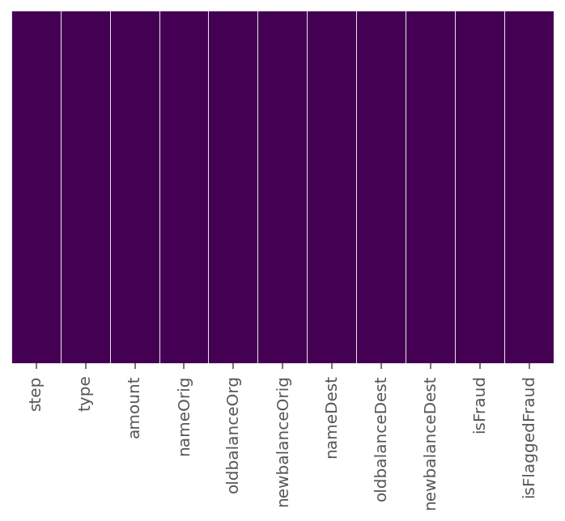

```python
#To check missing value
sns.heatmap(dataset.isnull(),cbar=False,yticklabels=False,cmap='viridis')
```

##### Inference:

- There are no null values inside the dataset.

|  | step | amount | oldbalanceOrg | newbalanceOrig | oldbalanceDest | newbalanceDest | isFraud | isFlaggedFraud |
| --- | --- | --- | --- | --- | --- | --- | --- | --- |
| step | 1.000000 | 0.022373 | -0.010058 | -0.010299 | 0.027665 | 0.025888 | 0.031578 | 0.003277 |
| amount | 0.022373 | 1.000000 | -0.002762 | -0.007861 | 0.294137 | 0.459304 | 0.076688 | 0.012295 |
| oldbalanceOrg | -0.010058 | -0.002762 | 1.000000 | 0.998803 | 0.066243 | 0.042029 | 0.010154 | 0.003835 |
| newbalanceOrig | -0.010299 | -0.007861 | 0.998803 | 1.000000 | 0.067812 | 0.041837 | -0.008148 | 0.003776 |
| oldbalanceDest | 0.027665 | 0.294137 | 0.066243 | 0.067812 | 1.000000 | 0.976569 | -0.005885 | -0.000513 |
| newbalanceDest | 0.025888 | 0.459304 | 0.042029 | 0.041837 | 0.976569 | 1.000000 | 0.000535 | -0.000529 |
| isFraud | 0.031578 | 0.076688 | 0.010154 | -0.008148 | -0.005885 | 0.000535 | 1.000000 | 0.044109 |
| isFlaggedFraud | 0.003277 | 0.012295 | 0.003835 | 0.003776 | -0.000513 | -0.000529 | 0.044109 | 1.000000 |

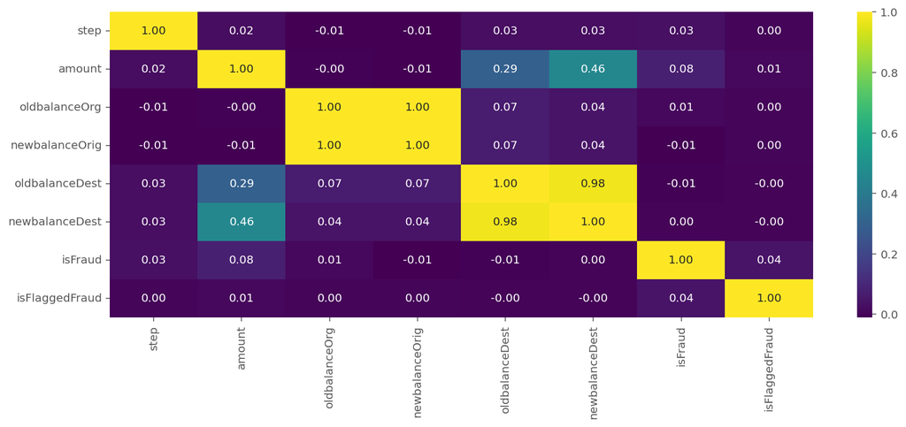

```python
plt.figure(figsize=(14,5))
corr= dataset.corr()
sns.heatmap(corr,cmap='viridis',annot=True,fmt='.2f')
corr
```

##### Inference:

- We can see only oldbalanceDest and newbalanceDest have strong linear relationship. oldbalanceOrg and newbalanceOrig also have strong relationship.
- newbalanceOrig, oldbalanceDest are both negatively correlated with isFraud.
- oldbalanceOrg, newbalanceOrig have negative correlation with amount.
- isFlaggedFraud, step, isFraud are uniformaliy distributed and there is no correlation with other variable. This can all be because dataset is imbalanced.

```python
dataset.duplicated(keep=False).sum()
```

```
0
```

##### Inference:

- There are no duplicates in the dataset.

```python
dataset.drop('isFraud', axis=1, inplace=True)
```

```python
#profile = ProfileReport(df = dataset)
#profile.to_file(output_file = "Fraud_transaction Profiling Report.html")
#print('Profiling Report Completed')
```

##### Inference:

### Profiling Report

- There are no missing cells in the dataset.
- There are no duplicate rows.
- There are 6 numerical and 5 categorical variable types.
- nameOrig has a high cardinality: 6353307 distinct values. nameDest has a high cardinality: 2722362 distinct values.
- oldbalanceDest, newbalanceDest is highly correlated with amount.
  - oldbalanceOrg is highly correlated with newbalanceOrig
  - oldbalanceDest is highly correlated with newbalanceDest
- type is highly correlated with newbalanceOrig
- amount is highly skewed (γ1 = 30.99394948)
- nameOrig is uniformly distributed
- oldbalanceOrg has 2102449 (33.0%) zeros
- newbalanceOrig has 3609566 (56.7%) zeros
- oldbalanceDest has 2704388 (42.5%) zeros
- newbalanceDest has 2439433 (38.3%) zeros
- Fraud Transaction are 8213 which is very less with respect to the dataset.
- Flagged Fraud Transaction are only 16 which is very less with respect to the dataset.

# Data Processing Or Data Preparation

- As from the dataset we are not fully satisfy with the isFraud column as it is correct or not. So, we will do Feature Analysis on it. We will make a new column with name 'Fraud_Check' where we will clearly classify fraud/Not Fraud data in it.
- We will check the dataset with 6 conditions to verify that the transactions is fraud or not. We will remove rows after every conditions gets true so that to get a better view of the left transaction in the dataset.

Lets discuss on the type of transactions in the dataset.

- **PAYMENT** - Payment is like when we pay to any merchant or to any customer by way of digital transactions like UPI. In our dataset we have been given Payment details of only merchants and they are not provide with any account balance details. So, without knowing the balance details we are not sure that the transactions is Fraud or not. So, we will just drop these transactions as they are no use to us for modeling.
- **CASH IN** - It happen when cash is deposited to someones account and his account balance gets increase. CASH IN affect only the origin account and not the destination account if that happen than those transaction will be termed as transfer not cash in. CASH IN only deals with origin account as it affect only the amount of origin account. It increases the balance at origin account. The bank do not consider CASH IN as a fraud because it is fully under the conscience of the customer and not the bank. And we are also not given with any details on how to set fraud, so we will just use the bank domain knowledge and will drop these type of transactions.
- **DEBIT** - A bank debit occurs when a bank customer uses the funds in their account, therefore reducing their account balance. Bank debits can be the result of checque payments, honored drafts, the withdrawal of funds from an account at a bank branch or via ATM, or the use of a debit card for merchant payments. So, withdraw of funds here is separated with CASH OUT, merchant payments is separated as PAYMENT. We are left with cheque payments and honored drafts, these both transactions are under the will of customer. Debit here only affect the origin account. Bank deals with these transaction as under the conscience of the sender. So, we can also drop these transactions as they cannot leads to Fraud.

**Fraud Can happen mostly on financial transactions from your account and without your knowledge. It occurs when a criminal gains access to your card number—and in some cases, personal identification number (PIN)—to make unauthorized purchases or withdraw cash from your account. So, these type of transactions can only happen under TRANSFER and CASH OUT.**

- **CASH OUT** - Fraudulent cash-out refers to the withdrawal of cash from a card through a fake purchase transaction that bypasses the interest charges and credit limits of cash advances set by the issuing bank. CASH OUT only deals with origin account. It helps the fraudster to cash out the money, they always try to drain out the account balance. we will take these transactions as fraud because they are draining the origin account balance and cashing out from the system. Same amount is being transfer and cash out.
- **TRANSFER** - In a money transfer fraud, the fraudster will approach you via email, call, WhatsApp or SMS and will lure you to access malicious links for making payments. These fake bank URLs will look almost identical to the original URL which makes it difficult to identify in first glance if you are not careful. An authorised push payment (APP) scam, also known as a bank transfer scam, occurs when you - knowingly or unwittingly - transfer money from your own bank account to one belonging to a scammer. Here also scammer transfer the amount and cash out.

**So, From above details we came up that FRAUD mostly happen under CASH out and TRANSFER. Our focus will be to check fraud under these type of transactions.

| **Condition 1** | Removing Payment type of transactions as it consists only merchants account and we do not have any balance detail. So, we will consierd these balance as not Fraud and will remove them from the copied … |
| --- | --- |
| **Condition 2** | In this will check the acccount with nill balance in Origin account and Destination account. We will remove these transactions as they are not fraud. No balance in Origin account leads to no transacti… |
| **Condition 3** | First we will replace all Origin account where the old balance and new bal is zero and amt is not equal to zero with NaN. As these transactions are not fraud as the origin account do not have balance.… |
| **Condition 4** | Here we will take both transfer and cash out type of transaction as one dataframe as they both are related to each other. A fraudster use this technique where they drain the origin customer account tr… |
| **Condition 5** | From the transfer and cash out left dataframe we will remove those transactions were old balance orig is less than amount as those are considered as not fraud because origin account balance is less no… |
| **Condition 6** | From, the left dataframe we will filter for TRANSFER type of transactions and than we will consider those transactions which amount is equal to difference in balance origin and difference in destinati… |

# Feature Extraction

```python
dataset_1= dataset.copy()
dataset_1
```

|  | step | type | amount | nameOrig | oldbalanceOrg | newbalanceOrig | nameDest | oldbalanceDest | newbalanceDest | isFlaggedFraud |
| --- | --- | --- | --- | --- | --- | --- | --- | --- | --- | --- |
| 0 | 1 | PAYMENT | 9839.64 | C1231006815 | 170136.00 | 160296.36 | M1979787155 | 0.00 | 0.00 | 0 |
| 1 | 1 | PAYMENT | 1864.28 | C1666544295 | 21249.00 | 19384.72 | M2044282225 | 0.00 | 0.00 | 0 |
| 2 | 1 | TRANSFER | 181.00 | C1305486145 | 181.00 | 0.00 | C553264065 | 0.00 | 0.00 | 0 |
| 3 | 1 | CASH_OUT | 181.00 | C840083671 | 181.00 | 0.00 | C38997010 | 21182.00 | 0.00 | 0 |
| 4 | 1 | PAYMENT | 11668.14 | C2048537720 | 41554.00 | 29885.86 | M1230701703 | 0.00 | 0.00 | 0 |
| ... | ... | ... | ... | ... | ... | ... | ... | ... | ... | ... |
| 6362615 | 743 | CASH_OUT | 339682.13 | C786484425 | 339682.13 | 0.00 | C776919290 | 0.00 | 339682.13 | 0 |
| 6362616 | 743 | TRANSFER | 6311409.28 | C1529008245 | 6311409.28 | 0.00 | C1881841831 | 0.00 | 0.00 | 0 |
| 6362617 | 743 | CASH_OUT | 6311409.28 | C1162922333 | 6311409.28 | 0.00 | C1365125890 | 68488.84 | 6379898.11 | 0 |
| 6362618 | 743 | TRANSFER | 850002.52 | C1685995037 | 850002.52 | 0.00 | C2080388513 | 0.00 | 0.00 | 0 |
| 6362619 | 743 | CASH_OUT | 850002.52 | C1280323807 | 850002.52 | 0.00 | C873221189 | 6510099.11 | 7360101.63 | 0 |

6362620 rows × 10 columns

# Condition 1

Removing Payment type of transactions as it consists only merchants account and we do not have any balance detail. So, we will consierd these balance as not Fraud and will remove them from the copied dataset. We will also remove DEBIT & CASH IN transactions as bank do not considered it as a fraud and they are under the will of the customer.

```python
def dest_cust(name_cust):
    if re.match('C',name_cust):
        return('C')
    else:
        return('M')
```

```python
dataset_1['dest_account']= dataset_1['nameDest'].apply(dest_cust)
dataset_1.groupby(['type', 'dest_account']).size().reset_index().rename(columns={0:'Count of Customer/Merchant '})
```

|  | type | dest_account | Count of Customer/Merchant |
| --- | --- | --- | --- |
| 0 | CASH_IN | C | 1399284 |
| 1 | CASH_OUT | C | 2237500 |
| 2 | DEBIT | C | 41432 |
| 3 | PAYMENT | M | 2151495 |
| 4 | TRANSFER | C | 532909 |

##### Inference:

- Only PAYMENT consists of the receiver is Merchant. And the count of transaction is quite large 2151495. We are also not given merchant account balance details. If the balance of merchant were given than we can check for fraud.
- From above we can see only PAYMENT consists Merchant account.

```python
# Remove Payment type transactions as it consists only Merchants and they are not fraud. We will also drop 'nameOrig' and
# 'nameDest' as it contain account detail.
dataset_new= dataset_1.loc[(dataset_1['type'] == 'TRANSFER') | (dataset_1['type'] == 'CASH_OUT')].drop(['nameOrig', 'nameDest'],
                                                                                                       axis = 1)
print('Old Data Shape:', dataset_1.shape)
print('New Data Shape:', dataset_new.shape)
dataset_new.head()
```

```
Old Data Shape: (6362620, 11)
New Data Shape: (2770409, 9)
```

|  | step | type | amount | oldbalanceOrg | newbalanceOrig | oldbalanceDest | newbalanceDest | isFlaggedFraud | dest_account |
| --- | --- | --- | --- | --- | --- | --- | --- | --- | --- |
| 2 | 1 | TRANSFER | 181.00 | 181.0 | 0.0 | 0.0 | 0.00 | 0 | C |
| 3 | 1 | CASH_OUT | 181.00 | 181.0 | 0.0 | 21182.0 | 0.00 | 0 | C |
| 15 | 1 | CASH_OUT | 229133.94 | 15325.0 | 0.0 | 5083.0 | 51513.44 | 0 | C |
| 19 | 1 | TRANSFER | 215310.30 | 705.0 | 0.0 | 22425.0 | 0.00 | 0 | C |
| 24 | 1 | TRANSFER | 311685.89 | 10835.0 | 0.0 | 6267.0 | 2719172.89 | 0 | C |

```python
values = dataset_new.type.value_counts()
values
```

```
CASH_OUT    2237500
TRANSFER     532909
Name: type, dtype: int64
```

#### Inference:

- Removing these transactions leads our dataset getting less which will help us to find fraud more easily & fast.
- Remove Payment as it consists only Merchant and we do not have any balance details. So, we will considerd these balance as not fraud and will remove them from dataset.
- Remove Payment type transactions as it consists only Merchants and they are not fraud.
- We will also drop 'nameOrig' and 'nameDest' as it contain account number details.
- We will also remove CASH IN as it only deals with origin account as it affect only the amount of origin account. It increases the balance at origin account. The bank do not consider CASH IN as a fraud because it is fully under the conscience of the customer and not the bank.
- As per discussion above we will also remove DEBIT. As bank debit occurs when a bank customer uses the funds in their account. Bank debits can be the result of cheque payments, honored drafts. Debit here only affect the origin account. Bank deals with these transaction as under the conscience of the sender. So, we can also drop these transactions as they cannot leads to Fraud and they are under the conscience of the customer.

# Condition 2

Account with nill balance in origin and destination. We will remove these transactions as not fraud. No balance in origin leads to no transactions in destinations.

```python
# Here we are checking if old balance origin = new balance origin = old balance destination = new balance destination = 0,
#if true than 1 else 0.
dataset_new['each_account_nill']= np.where((dataset_new['oldbalanceOrg'] == 0) & (dataset_new['newbalanceOrig'] == 0) &
                                                   (dataset_new['oldbalanceDest'] == 0) & (dataset_new['newbalanceDest'] == 0)
                                           ,1 , 0)
```

```python
zero_bal_account=dataset_new.loc[dataset_new['each_account_nill']==1]
print('Account with nill bal on origin and destination:', zero_bal_account.shape)
```

```
Account with nill bal on origin and destination: (30, 10)
```

```python
#We will remove these rows from the dataset as they are not fraud.
ind1=zero_bal_account.index
dataset_new.drop(ind1, inplace=True)
```

```python
values = dataset_new.type.value_counts()
values
```

```
CASH_OUT    2237475
TRANSFER     532904
Name: type, dtype: int64
```

#### Inference:

- Transactions with nill balance in origin and destination have been removed as those are not fraud. No balance in origin leads to no transactions in destinations.

# Condition 3

First we will replace all Origin account where the old balance and new bal is zero and amt is not equal to zero with NaN. As these transactions are not fraud as the origin account do not have balance. We will remove these transactions. We will also check destination account where old balance and new balance is zero but amount is not equal to zero with -1. As these account Face true Fraud. Here Amount is transferred but not received or not affected the destination account. We will check these transactions step by step.

```python
dataset_new['bal_diff_orig']= abs(dataset_new['oldbalanceOrg'] - dataset_new['newbalanceOrig'])
dataset_new['bal_diff_dest']= abs(dataset_new['oldbalanceDest'] - dataset_new['newbalanceDest'])
```

```python
# Replacing1
dataset_new.loc[(dataset_new['oldbalanceOrg'] == 0) & (dataset_new['newbalanceOrig'] == 0) &
                (dataset_new['amount'] != 0), ['oldbalanceOrg', 'newbalanceOrig']] = np.nan
```

```python
# Replacing2
dataset_new.loc[(dataset_new['oldbalanceDest'] == 0) & (dataset_new['newbalanceDest'] == 0) &
                (dataset_new['amount'] != 0), ['oldbalanceDest', 'newbalanceDest']] = - 1
```

```python
df_null = pd.DataFrame(dataset_new.isnull().sum(), columns = ['Frequency'])
df_null.T
```

|  | step | type | amount | oldbalanceOrg | newbalanceOrig | oldbalanceDest | newbalanceDest | isFlaggedFraud | dest_account | each_account_nill | bal_diff_orig | bal_diff_dest |
| --- | --- | --- | --- | --- | --- | --- | --- | --- | --- | --- | --- | --- |
| Frequency | 0 | 0 | 0 | 1308542 | 1308542 | 0 | 0 | 0 | 0 | 0 | 0 | 0 |

```python
print('Old Data Shape:', dataset_new.shape)
dataset_new.dropna(axis = 0, inplace = True)
print('New Data Shape: ', dataset_new.shape)
df_null = pd.DataFrame(dataset_new.isnull().sum(), columns = ['Frequency'])
df_null.transpose()
```

```
Old Data Shape: (2770379, 12)
New Data Shape:  (1461837, 12)
```

|  | step | type | amount | oldbalanceOrg | newbalanceOrig | oldbalanceDest | newbalanceDest | isFlaggedFraud | dest_account | each_account_nill | bal_diff_orig | bal_diff_dest |
| --- | --- | --- | --- | --- | --- | --- | --- | --- | --- | --- | --- | --- |
| Frequency | 0 | 0 | 0 | 0 | 0 | 0 | 0 | 0 | 0 | 0 | 0 | 0 |

#### Inference:

- Replacing1 - In first replacing we have checked that if old balance origin is zero and new balance origin is zero and amount is not equal to zero, at that case these transactions are considered not fraud as the origin account do not consists any balance so no transactions will happen. We will remove these transactions.
- Replacing2 - Here, we have checked that if old balance of destination is zero and new balance of destination is zero and amount is not equal to zero at that case these transactions are considered as fraud because amount transferred not received or not affected in the destination account.

# Condition 4

Here we will take both transfer and cash out type of transaction as one dataframe as they both are related to each other. A fraudster use this technique where they drain the origin customer account transfer it and cash out from the system. We will keep these transaction seprately and remove it from combined dataframe.

```python
df_TRANSFER_CASH_OUT=dataset_new.copy()
df_TRANSFER_CASH_OUT
```

|  | step | type | amount | oldbalanceOrg | newbalanceOrig | oldbalanceDest | newbalanceDest | isFlaggedFraud | dest_account | each_account_nill | bal_diff_orig | bal_diff_dest |
| --- | --- | --- | --- | --- | --- | --- | --- | --- | --- | --- | --- | --- |
| 2 | 1 | TRANSFER | 181.00 | 181.00 | 0.0 | -1.00 | -1.00 | 0 | C | 0 | 181.00 | 0.00 |
| 3 | 1 | CASH_OUT | 181.00 | 181.00 | 0.0 | 21182.00 | 0.00 | 0 | C | 0 | 181.00 | 21182.00 |
| 15 | 1 | CASH_OUT | 229133.94 | 15325.00 | 0.0 | 5083.00 | 51513.44 | 0 | C | 0 | 15325.00 | 46430.44 |
| 19 | 1 | TRANSFER | 215310.30 | 705.00 | 0.0 | 22425.00 | 0.00 | 0 | C | 0 | 705.00 | 22425.00 |
| 24 | 1 | TRANSFER | 311685.89 | 10835.00 | 0.0 | 6267.00 | 2719172.89 | 0 | C | 0 | 10835.00 | 2712905.89 |
| ... | ... | ... | ... | ... | ... | ... | ... | ... | ... | ... | ... | ... |
| 6362615 | 743 | CASH_OUT | 339682.13 | 339682.13 | 0.0 | 0.00 | 339682.13 | 0 | C | 0 | 339682.13 | 339682.13 |
| 6362616 | 743 | TRANSFER | 6311409.28 | 6311409.28 | 0.0 | -1.00 | -1.00 | 0 | C | 0 | 6311409.28 | 0.00 |
| 6362617 | 743 | CASH_OUT | 6311409.28 | 6311409.28 | 0.0 | 68488.84 | 6379898.11 | 0 | C | 0 | 6311409.28 | 6311409.27 |
| 6362618 | 743 | TRANSFER | 850002.52 | 850002.52 | 0.0 | -1.00 | -1.00 | 0 | C | 0 | 850002.52 | 0.00 |
| 6362619 | 743 | CASH_OUT | 850002.52 | 850002.52 | 0.0 | 6510099.11 | 7360101.63 | 0 | C | 0 | 850002.52 | 850002.52 |

1461837 rows × 12 columns

- Here we will take both transfer and cash out type of transaction as one dataframe as they both are related to each other. A fraudster use this technique where they drain the origin customer account transfer it and cash out from the system
- While looking at the dataframe above you will notice that amount is first Transfer and then Cash Out. These transactions are considered as Fraud.
- So, we will create a column where drain of origin account is seen.

```python
values = df_TRANSFER_CASH_OUT.type.value_counts()
values
```

```
CASH_OUT    1211711
TRANSFER     250126
Name: type, dtype: int64
```

```python
df_TRANSFER_CASH_OUT['drain_orig_account']=np.where((df_TRANSFER_CASH_OUT['oldbalanceOrg']==df_TRANSFER_CASH_OUT['amount']) & \
                                                 (df_TRANSFER_CASH_OUT['newbalanceOrig']==0),1,0)
```

```python
fraudcheck1=df_TRANSFER_CASH_OUT.loc[df_TRANSFER_CASH_OUT['drain_orig_account']==1]
```

```python
print('Transactions with Fraud:', fraudcheck1.shape)
fraudcheck1
```

```
Transactions with Fraud: (8018, 13)
```

|  | step | type | amount | oldbalanceOrg | newbalanceOrig | oldbalanceDest | newbalanceDest | isFlaggedFraud | dest_account | each_account_nill | bal_diff_orig | bal_diff_dest | drain_orig_account |
| --- | --- | --- | --- | --- | --- | --- | --- | --- | --- | --- | --- | --- | --- |
| 2 | 1 | TRANSFER | 181.00 | 181.00 | 0.0 | -1.00 | -1.00 | 0 | C | 0 | 181.00 | 0.00 | 1 |
| 3 | 1 | CASH_OUT | 181.00 | 181.00 | 0.0 | 21182.00 | 0.00 | 0 | C | 0 | 181.00 | 21182.00 | 1 |
| 251 | 1 | TRANSFER | 2806.00 | 2806.00 | 0.0 | -1.00 | -1.00 | 0 | C | 0 | 2806.00 | 0.00 | 1 |
| 252 | 1 | CASH_OUT | 2806.00 | 2806.00 | 0.0 | 26202.00 | 0.00 | 0 | C | 0 | 2806.00 | 26202.00 | 1 |
| 680 | 1 | TRANSFER | 20128.00 | 20128.00 | 0.0 | -1.00 | -1.00 | 0 | C | 0 | 20128.00 | 0.00 | 1 |
| ... | ... | ... | ... | ... | ... | ... | ... | ... | ... | ... | ... | ... | ... |
| 6362615 | 743 | CASH_OUT | 339682.13 | 339682.13 | 0.0 | 0.00 | 339682.13 | 0 | C | 0 | 339682.13 | 339682.13 | 1 |
| 6362616 | 743 | TRANSFER | 6311409.28 | 6311409.28 | 0.0 | -1.00 | -1.00 | 0 | C | 0 | 6311409.28 | 0.00 | 1 |
| 6362617 | 743 | CASH_OUT | 6311409.28 | 6311409.28 | 0.0 | 68488.84 | 6379898.11 | 0 | C | 0 | 6311409.28 | 6311409.27 | 1 |
| 6362618 | 743 | TRANSFER | 850002.52 | 850002.52 | 0.0 | -1.00 | -1.00 | 0 | C | 0 | 850002.52 | 0.00 | 1 |
| 6362619 | 743 | CASH_OUT | 850002.52 | 850002.52 | 0.0 | 6510099.11 | 7360101.63 | 0 | C | 0 | 850002.52 | 850002.52 | 1 |

8018 rows × 13 columns

#### Inference:

- So, we will take these transactions as fraud because they are draining the origin account balance and cashing out from the system. Same amount is being transfer and cash out.

# Condition 5

From the transfer and cash out left dataframe we will remove those transactions were old balance orig is less than amount as those are considered as not fraud because origin account balance is less not able to transfer the amount rest we will check for fraud.

```python
# We will remove the above fraud transactions and deal with the rest transactions.
ind2=fraudcheck1.index
df_TRANSFER_CASH_OUT.drop(ind2, inplace=True)
```

```python
values = df_TRANSFER_CASH_OUT.type.value_counts()
values
```

```
CASH_OUT    1207626
TRANSFER     246193
Name: type, dtype: int64
```

- Now, we will remove those transactions where old balance origin is less than amount as those are considered as not fraud because origin account balance is less not able to transfer the amount. Rest we will check for fraud.

```python
# 1 Not fraud as origin account do not have balance
df_TRANSFER_CASH_OUT['less_origin_bal']=np.where(df_TRANSFER_CASH_OUT['oldbalanceOrg']<df_TRANSFER_CASH_OUT['amount'], 1, 0)
```

```python
# Not Fraud because amt less in orig account not able to transfer
origin_bal_less=df_TRANSFER_CASH_OUT.loc[df_TRANSFER_CASH_OUT['less_origin_bal']==1]
origin_bal_less
```

|  | step | type | amount | oldbalanceOrg | newbalanceOrig | oldbalanceDest | newbalanceDest | isFlaggedFraud | dest_account | each_account_nill | bal_diff_orig | bal_diff_dest | drain_orig_account | less_origin_bal |
| --- | --- | --- | --- | --- | --- | --- | --- | --- | --- | --- | --- | --- | --- | --- |
| 15 | 1 | CASH_OUT | 229133.94 | 15325.00 | 0.0 | 5083.00 | 51513.44 | 0 | C | 0 | 15325.00 | 46430.44 | 0 | 1 |
| 19 | 1 | TRANSFER | 215310.30 | 705.00 | 0.0 | 22425.00 | 0.00 | 0 | C | 0 | 705.00 | 22425.00 | 0 | 1 |
| 24 | 1 | TRANSFER | 311685.89 | 10835.00 | 0.0 | 6267.00 | 2719172.89 | 0 | C | 0 | 10835.00 | 2712905.89 | 0 | 1 |
| 42 | 1 | CASH_OUT | 110414.71 | 26845.41 | 0.0 | 288800.00 | 2415.16 | 0 | C | 0 | 26845.41 | 286384.84 | 0 | 1 |
| 47 | 1 | CASH_OUT | 56953.90 | 1942.02 | 0.0 | 70253.00 | 64106.18 | 0 | C | 0 | 1942.02 | 6146.82 | 0 | 1 |
| ... | ... | ... | ... | ... | ... | ... | ... | ... | ... | ... | ... | ... | ... | ... |
| 6362313 | 718 | CASH_OUT | 111963.72 | 4514.00 | 0.0 | 154925.27 | 266888.99 | 0 | C | 0 | 4514.00 | 111963.72 | 0 | 1 |
| 6362317 | 718 | CASH_OUT | 317177.48 | 170.00 | 0.0 | 345042.13 | 662219.61 | 0 | C | 0 | 170.00 | 317177.48 | 0 | 1 |
| 6362320 | 718 | CASH_OUT | 159188.22 | 3859.00 | 0.0 | 0.00 | 159188.22 | 0 | C | 0 | 3859.00 | 159188.22 | 0 | 1 |
| 6362321 | 718 | CASH_OUT | 186273.84 | 168046.00 | 0.0 | 24893.67 | 211167.51 | 0 | C | 0 | 168046.00 | 186273.84 | 0 | 1 |
| 6362322 | 718 | TRANSFER | 82096.45 | 13492.00 | 0.0 | 0.00 | 82096.45 | 0 | C | 0 | 13492.00 | 82096.45 | 0 | 1 |

1180068 rows × 14 columns

#### Inference:

- Here, we have removed those transactions where old balance origin is less than amount as those are considered as not fraud because origin account balance is less not able to transfer the amount.

# Condition 6

From, the left dataframe we will filter for TRANSFER type of transactions and than we will consider those transactions which amount is equal to difference in balance origin and difference in destination balance is zero. That means those amount which are debited from origin account but have not been affected in the destination account. Those transaction will be considered as fraud.

```python
#We will drop those rows from the dataframe Not Fraud.
ind3=origin_bal_less.index
df_TRANSFER_CASH_OUT.drop(ind3, inplace=True)
```

```python
values = df_TRANSFER_CASH_OUT.type.value_counts()
values
```

```
CASH_OUT    252287
TRANSFER     21464
Name: type, dtype: int64
```

- Now we will take only TRANSFER transactions.
- We will check transactions whose amount is debited but not transfer to destination account.

```python
df_TRANSFER=df_TRANSFER_CASH_OUT.loc[df_TRANSFER_CASH_OUT['type']=='TRANSFER']
```

```python
#Amount deducted from origin but not received at destination
df_TRANSFER['fraud_check']=np.where((df_TRANSFER['amount']==df_TRANSFER['bal_diff_orig']) &
                                    (df_TRANSFER['bal_diff_dest']==0),1,0)
```

```python
fraudcheck2=df_TRANSFER.loc[df_TRANSFER['fraud_check']==1]
fraudcheck2
```

|  | step | type | amount | oldbalanceOrg | newbalanceOrig | oldbalanceDest | newbalanceDest | isFlaggedFraud | dest_account | each_account_nill | bal_diff_orig | bal_diff_dest | drain_orig_account | less_origin_bal | fraud_check |
| --- | --- | --- | --- | --- | --- | --- | --- | --- | --- | --- | --- | --- | --- | --- | --- |
| 4440 | 4 | TRANSFER | 10000000.00 | 12930418.44 | 2930418.44 | -1.0 | -1.0 | 0 | C | 0 | 10000000.00 | 0.0 | 0 | 0 | 1 |
| 60138 | 9 | TRANSFER | 59270.81 | 120447.00 | 61176.19 | -1.0 | -1.0 | 0 | C | 0 | 59270.81 | 0.0 | 0 | 0 | 1 |
| 102289 | 10 | TRANSFER | 273367.98 | 2833932.61 | 2560564.63 | -1.0 | -1.0 | 0 | C | 0 | 273367.98 | 0.0 | 0 | 0 | 1 |
| 138369 | 11 | TRANSFER | 50519.28 | 77109.00 | 26589.72 | -1.0 | -1.0 | 0 | C | 0 | 50519.28 | 0.0 | 0 | 0 | 1 |
| 236719 | 14 | TRANSFER | 135077.57 | 183075.00 | 47997.43 | -1.0 | -1.0 | 0 | C | 0 | 135077.57 | 0.0 | 0 | 0 | 1 |
| ... | ... | ... | ... | ... | ... | ... | ... | ... | ... | ... | ... | ... | ... | ... | ... |
| 6362528 | 736 | TRANSFER | 10000000.00 | 11314660.84 | 1314660.84 | -1.0 | -1.0 | 0 | C | 0 | 10000000.00 | 0.0 | 0 | 0 | 1 |
| 6362576 | 741 | TRANSFER | 10000000.00 | 45674547.89 | 35674547.89 | -1.0 | -1.0 | 0 | C | 0 | 10000000.00 | 0.0 | 0 | 0 | 1 |
| 6362578 | 741 | TRANSFER | 10000000.00 | 35674547.89 | 25674547.89 | -1.0 | -1.0 | 0 | C | 0 | 10000000.00 | 0.0 | 0 | 0 | 1 |
| 6362580 | 741 | TRANSFER | 10000000.00 | 25674547.89 | 15674547.89 | -1.0 | -1.0 | 0 | C | 0 | 10000000.00 | 0.0 | 0 | 0 | 1 |
| 6362582 | 741 | TRANSFER | 10000000.00 | 15674547.89 | 5674547.89 | -1.0 | -1.0 | 0 | C | 0 | 10000000.00 | 0.0 | 0 | 0 | 1 |

130 rows × 15 columns

#### Inference:

- Here we are considering those amounts which are equal to difference in balance of origin but those have not been affected in the destination account. Those transactions will be considered as fraud.

# Updating Our Original Dataset

We will create a column 'Fraud_check' and we will update rows which we have found as fraud.

```python
dataset["Fraud_check"] = pd.NaT
```

```python
index1= fraudcheck1.index
index2= fraudcheck2.index
```

```python
dataset.loc[index1, ['Fraud_check']] = 'Fraud'
dataset.loc[index2, ['Fraud_check']] = 'Fraud'
```

```python
dataset['Fraud_check']= dataset['Fraud_check'].fillna('Not_Fraud')
```

```python
dataset
```

|  | step | type | amount | nameOrig | oldbalanceOrg | newbalanceOrig | nameDest | oldbalanceDest | newbalanceDest | isFlaggedFraud | Fraud_check |
| --- | --- | --- | --- | --- | --- | --- | --- | --- | --- | --- | --- |
| 0 | 1 | PAYMENT | 9839.64 | C1231006815 | 170136.00 | 160296.36 | M1979787155 | 0.00 | 0.00 | 0 | Not_Fraud |
| 1 | 1 | PAYMENT | 1864.28 | C1666544295 | 21249.00 | 19384.72 | M2044282225 | 0.00 | 0.00 | 0 | Not_Fraud |
| 2 | 1 | TRANSFER | 181.00 | C1305486145 | 181.00 | 0.00 | C553264065 | 0.00 | 0.00 | 0 | Fraud |
| 3 | 1 | CASH_OUT | 181.00 | C840083671 | 181.00 | 0.00 | C38997010 | 21182.00 | 0.00 | 0 | Fraud |
| 4 | 1 | PAYMENT | 11668.14 | C2048537720 | 41554.00 | 29885.86 | M1230701703 | 0.00 | 0.00 | 0 | Not_Fraud |
| ... | ... | ... | ... | ... | ... | ... | ... | ... | ... | ... | ... |
| 6362615 | 743 | CASH_OUT | 339682.13 | C786484425 | 339682.13 | 0.00 | C776919290 | 0.00 | 339682.13 | 0 | Fraud |
| 6362616 | 743 | TRANSFER | 6311409.28 | C1529008245 | 6311409.28 | 0.00 | C1881841831 | 0.00 | 0.00 | 0 | Fraud |
| 6362617 | 743 | CASH_OUT | 6311409.28 | C1162922333 | 6311409.28 | 0.00 | C1365125890 | 68488.84 | 6379898.11 | 0 | Fraud |
| 6362618 | 743 | TRANSFER | 850002.52 | C1685995037 | 850002.52 | 0.00 | C2080388513 | 0.00 | 0.00 | 0 | Fraud |
| 6362619 | 743 | CASH_OUT | 850002.52 | C1280323807 | 850002.52 | 0.00 | C873221189 | 6510099.11 | 7360101.63 | 0 | Fraud |

6362620 rows × 11 columns

```python
dataset.groupby(['Fraud_check']).size().reset_index().rename(columns={0:'Count of Fraud/Not Fraud'})
```

|  | Fraud_check | Count of Fraud/Not Fraud |
| --- | --- | --- |
| 0 | Fraud | 8148 |
| 1 | Not_Fraud | 6354472 |

#### Inference:

- The total no of fraud is 8148.

## Feature engineering

With the available information it is hard to train the model and get better results. Hence we move onto create new features by altering the existing features.

1. **Difference in balance:** It is an universal truth that the amount debited from senders account gets credited into the receivers account without any deviation in cents. But what if there is a deviation incase of the amount debited and credited. Some could be due to the charges levied by the service providers, yet we need to flag such unusual instances
2. **Merchant indicator:** The customer ids in receiver starts with 'M' which means that they are merchants and they obviously will have a lot of receiving transactions. So we also flag whenever there is a merchant receiver.
3. **Type indicator:** Type id based on transaction type.

These new features turn out to be important in obtaining the best performance from the ML algorithm that we will finally use.

```python
# On the basis of Difference in Balance of Receiver and Sender
dataset['bal_diff_orig']= abs(dataset['oldbalanceOrg'] - dataset['newbalanceOrig'])
dataset['bal_diff_dest']= abs(dataset['oldbalanceDest'] - dataset['newbalanceDest'])
```

```python
# TypeId based on type of transactions
dataset['typeId'] = dataset['type'].factorize()[0]
```

```python
# Customer and Merchant indicator
dataset['dest_account']= dataset['nameDest'].apply(dest_cust)
```

## Checking on Step Data

```python
# Create new feature to document hour (of the 1-month simulation)
dataset['hour'] = dataset['step'].map(lambda x: x//720)
```

```python
# Create new feature to document day (of the 1-month simulation)
dataset['day'] = dataset['step'].map(lambda x: x//24)
```

```python
# Create new feature weekday (of the 7-days simulation)
dataset['weekday'] = dataset['step'].map(lambda x: x//168)
```

```python
# Create new feature sin_hour
dataset['sin_hour'] = np.sin((math.pi * dataset['step'])/(30 * 24))
```

```python
# Create new feature cos_hour
dataset['cos_hour'] = np.cos((math.pi*dataset['step'])/(30 * 24))
```

```python
# Create new feature sin_weekday
dataset['sin_weekday'] = dataset['weekday'].apply(lambda x: math.sin(math.radians(x)))
```

```python
# Create new feature cos_weekday
dataset['cos_weekday'] = dataset['weekday'].apply(lambda x: math.cos(math.radians(x)))
```

#### Inference:

The dataset spans over one month, with the feature step presenting the number of hours between each transaction and the first transaction in the dataset. It does not reflect directly enough all useful information, and is a good candidate for additional feature engineering. The original feature list is extended with seven features engineered and encoded from the step feature.

```python
dataset['Fraud_checkId'] = dataset['Fraud_check'].factorize()[0]
```

```python
dataset['Fraud_checkId'] = dataset['Fraud_checkId'].astype('bool')
```

# EDA On Features

## Distribution Plot on Step

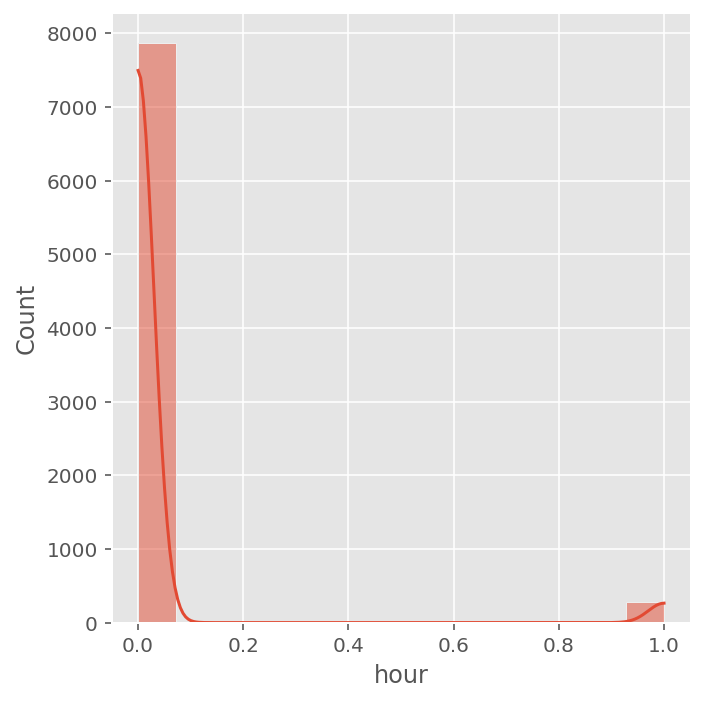

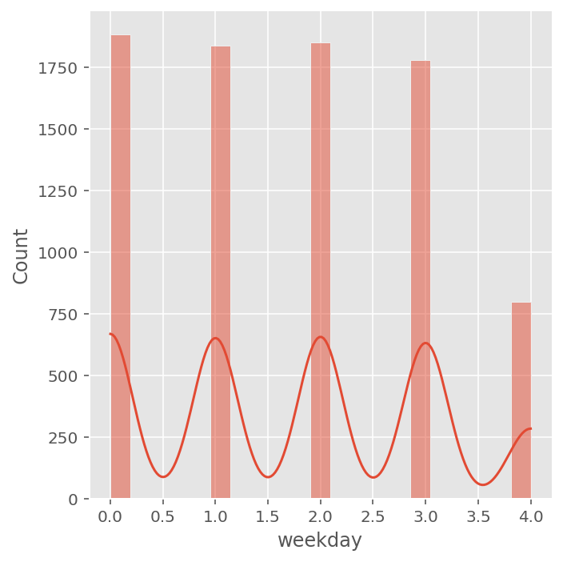

```python
day_fraud=dataset.loc[dataset['Fraud_checkId']==1].hour
sns.displot(day_fraud, kde=True)
day_fraud=dataset.loc[dataset['Fraud_checkId']==1].weekday
sns.displot(day_fraud, kde=True)
```

#### Inference:

- hour and weekday, do not reflect cyclic nature of time

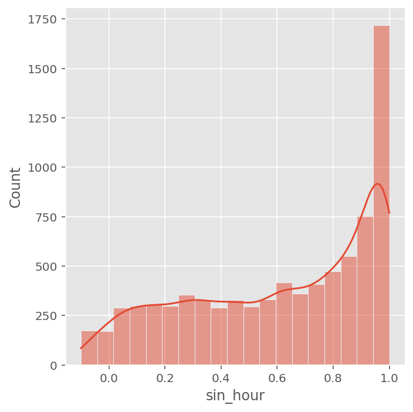

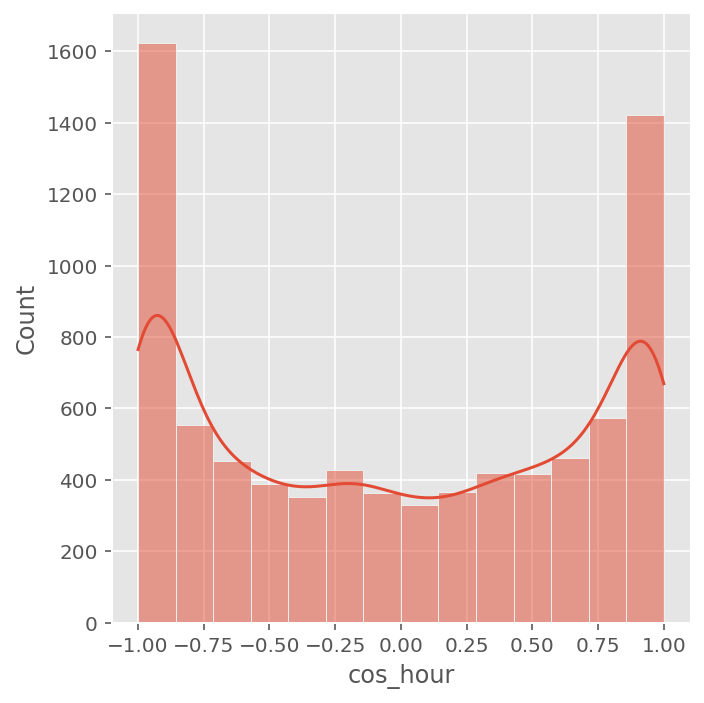

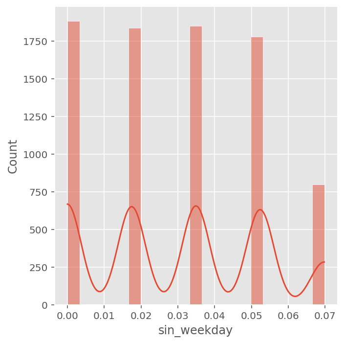

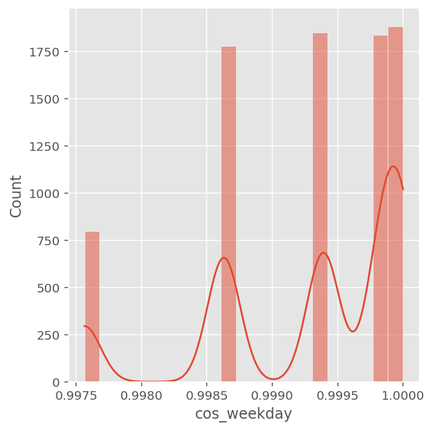

```python
day_fraud=dataset.loc[dataset['Fraud_checkId']==1].sin_hour
sns.displot(day_fraud, kde=True)
day_fraud=dataset.loc[dataset['Fraud_checkId']==1].cos_hour
sns.displot(day_fraud, kde=True)
day_fraud=dataset.loc[dataset['Fraud_checkId']==1].sin_weekday
sns.displot(day_fraud, kde=True)
day_fraud=dataset.loc[dataset['Fraud_checkId']==1].cos_weekday
sns.displot(day_fraud, kde=True)
```

#### Inference:

```python
day_fraud= dataset[dataset['Fraud_checkId']==1].groupby(['day']).size().reset_index().rename(columns={0:'Count of Fraud'})
day_fraud.sort_values(by='Count of Fraud', ascending=False)
```

|  | day | Count of Fraud |
| --- | --- | --- |
| 16 | 16 | 312 |
| 2 | 2 | 306 |
| 1 | 1 | 297 |
| 11 | 11 | 296 |
| 6 | 6 | 280 |
| 30 | 30 | 277 |
| 25 | 25 | 277 |
| 23 | 23 | 274 |
| 3 | 3 | 272 |
| 9 | 9 | 272 |
| 26 | 26 | 271 |
| 17 | 17 | 271 |
| 7 | 7 | 268 |
| 20 | 20 | 266 |
| 10 | 10 | 265 |
| 29 | 29 | 262 |
| 28 | 28 | 260 |
| 14 | 14 | 259 |
| 8 | 8 | 255 |
| 0 | 0 | 254 |
| 15 | 15 | 254 |
| 27 | 27 | 253 |
| 21 | 21 | 251 |
| 19 | 19 | 248 |
| 4 | 4 | 244 |
| 12 | 12 | 242 |
| 18 | 18 | 240 |
| 13 | 13 | 238 |
| 24 | 24 | 234 |
| 5 | 5 | 230 |
| 22 | 22 | 220 |

## Box Plot for Numerical Features

```python
df1=dataset.select_dtypes(exclude=['object'])
```

```python
df1['Fraud_checkId'] = df1['Fraud_checkId'].astype('int64')
```

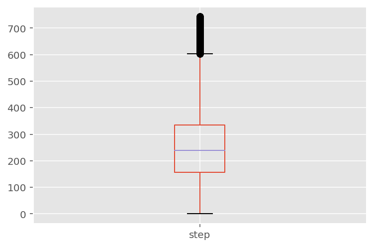

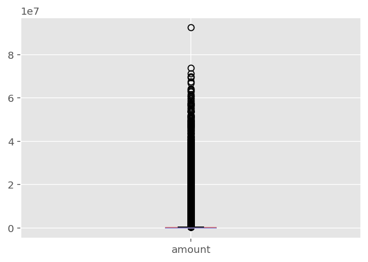

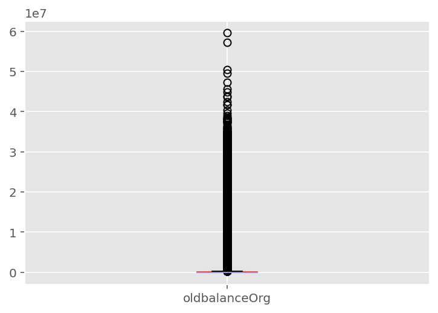

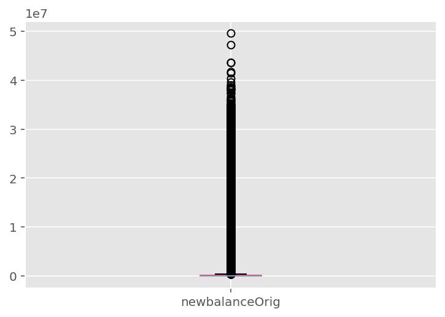

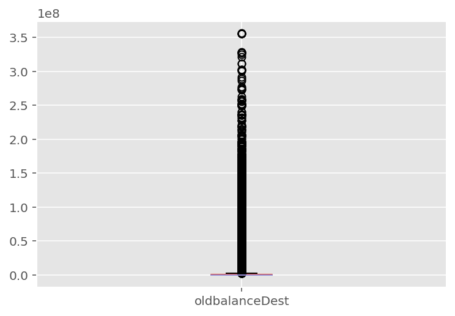

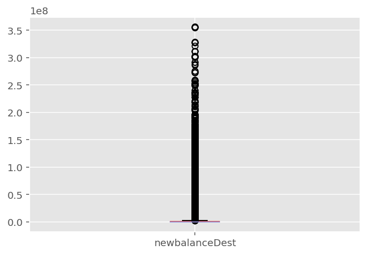

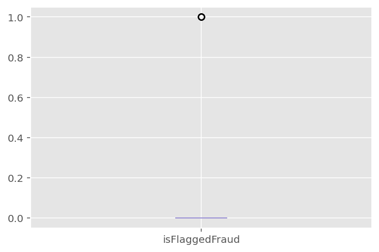

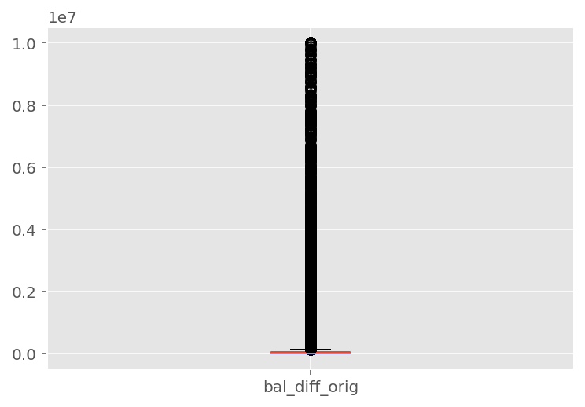

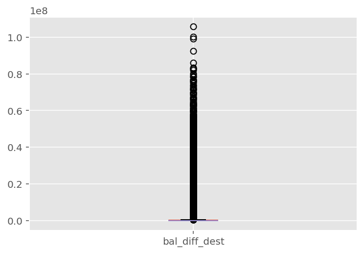

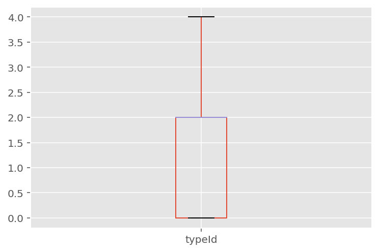

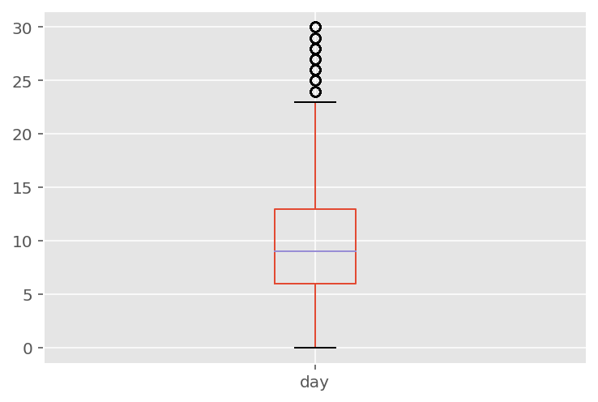

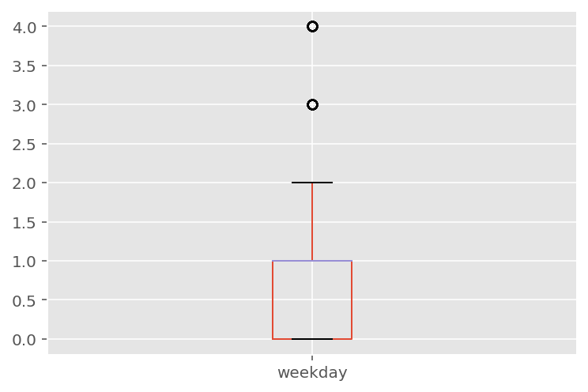

[6 more figures not shown]

```python
for column in df1:
    plt.figure()
    df1.boxplot([column])
```

#### Inference:

- The box plots show that the number of outliers for nearly all original dataset features are really high. This indicates that a contamination factor used in the later methods should not be too low.
- Based on box plots, it can also be concluded that none of the features is symmetrically distributed, and that the Elliptic Envelope method is not suitable for this dataset.
- The box plots show that the number of outliers for nearly all original dataset features are really high.
- It can also be concluded that none of the features is symmetrically distributed.
- box plots indicate that features amount, oldbalanceOrg, newbalanceOrig, oldbalanceDest and newbalanceDest are highly skewed, and they should be further processed before training machine learning models.

## Checking with the Customer and Merchant who is facing the fraud, and in which category type.

```python
dataset
```

|  | step | type | amount | nameOrig | oldbalanceOrg | newbalanceOrig | nameDest | oldbalanceDest | newbalanceDest | isFlaggedFraud | ... | typeId | dest_account | day | weekday | sin_hour | cos_hour | sin_weekday | cos_weekday | Fraud_checkId | hour |
| --- | --- | --- | --- | --- | --- | --- | --- | --- | --- | --- | --- | --- | --- | --- | --- | --- | --- | --- | --- | --- | --- |
| 0 | 1 | PAYMENT | 9839.64 | C1231006815 | 170136.00 | 160296.36 | M1979787155 | 0.00 | 0.00 | 0 | ... | 0 | M | 0 | 0 | 0.004363 | 0.999990 | 0.000000 | 1.000000 | False | 0 |
| 1 | 1 | PAYMENT | 1864.28 | C1666544295 | 21249.00 | 19384.72 | M2044282225 | 0.00 | 0.00 | 0 | ... | 0 | M | 0 | 0 | 0.004363 | 0.999990 | 0.000000 | 1.000000 | False | 0 |
| 2 | 1 | TRANSFER | 181.00 | C1305486145 | 181.00 | 0.00 | C553264065 | 0.00 | 0.00 | 0 | ... | 1 | C | 0 | 0 | 0.004363 | 0.999990 | 0.000000 | 1.000000 | True | 0 |
| 3 | 1 | CASH_OUT | 181.00 | C840083671 | 181.00 | 0.00 | C38997010 | 21182.00 | 0.00 | 0 | ... | 2 | C | 0 | 0 | 0.004363 | 0.999990 | 0.000000 | 1.000000 | True | 0 |
| 4 | 1 | PAYMENT | 11668.14 | C2048537720 | 41554.00 | 29885.86 | M1230701703 | 0.00 | 0.00 | 0 | ... | 0 | M | 0 | 0 | 0.004363 | 0.999990 | 0.000000 | 1.000000 | False | 0 |
| ... | ... | ... | ... | ... | ... | ... | ... | ... | ... | ... | ... | ... | ... | ... | ... | ... | ... | ... | ... | ... | ... |
| 6362615 | 743 | CASH_OUT | 339682.13 | C786484425 | 339682.13 | 0.00 | C776919290 | 0.00 | 339682.13 | 0 | ... | 2 | C | 30 | 4 | -0.100188 | -0.994969 | 0.069756 | 0.997564 | True | 1 |
| 6362616 | 743 | TRANSFER | 6311409.28 | C1529008245 | 6311409.28 | 0.00 | C1881841831 | 0.00 | 0.00 | 0 | ... | 1 | C | 30 | 4 | -0.100188 | -0.994969 | 0.069756 | 0.997564 | True | 1 |
| 6362617 | 743 | CASH_OUT | 6311409.28 | C1162922333 | 6311409.28 | 0.00 | C1365125890 | 68488.84 | 6379898.11 | 0 | ... | 2 | C | 30 | 4 | -0.100188 | -0.994969 | 0.069756 | 0.997564 | True | 1 |
| 6362618 | 743 | TRANSFER | 850002.52 | C1685995037 | 850002.52 | 0.00 | C2080388513 | 0.00 | 0.00 | 0 | ... | 1 | C | 30 | 4 | -0.100188 | -0.994969 | 0.069756 | 0.997564 | True | 1 |
| 6362619 | 743 | CASH_OUT | 850002.52 | C1280323807 | 850002.52 | 0.00 | C873221189 | 6510099.11 | 7360101.63 | 0 | ... | 2 | C | 30 | 4 | -0.100188 | -0.994969 | 0.069756 | 0.997564 | True | 1 |

6362620 rows × 23 columns

```python
dataset.groupby(['Fraud_check', 'type', 'dest_account']).size().reset_index().rename(columns={0:'Count of Customer/Merchant '})
```

|  | Fraud_check | type | dest_account | Count of Customer/Merchant |
| --- | --- | --- | --- | --- |
| 0 | Fraud | CASH_OUT | C | 4085 |
| 1 | Fraud | TRANSFER | C | 4063 |
| 2 | Not_Fraud | CASH_IN | C | 1399284 |
| 3 | Not_Fraud | CASH_OUT | C | 2233415 |
| 4 | Not_Fraud | DEBIT | C | 41432 |
| 5 | Not_Fraud | PAYMENT | M | 2151495 |
| 6 | Not_Fraud | TRANSFER | C | 528846 |

##### Inference:

- Only PAYMENT consists of the receiver is Merchant. And the count of transaction is quite large 2151495. We are also not given merchant account balance details.
- The mostly fraud transactions are in CASH_OUT & TRANSFER type.

```python
dataset[dataset['isFlaggedFraud']== 1].groupby(['isFlaggedFraud', 'type' ,'dest_account']).size().reset_index().rename(columns={0:'Count of Flagged Customer'})
```

|  | isFlaggedFraud | type | dest_account | Count of Flagged Customer |
| --- | --- | --- | --- | --- |
| 0 | 1 | TRANSFER | C | 16 |

##### Inference:

- There are only 16 transaction which is considered as True Flagged Fraud Customer and only in TRANSFER category. Here also customer is only facing the issue not merchant.

## Data Distribution

```python
numerical_df= dataset.copy()
numerical_df.drop(['sin_hour','cos_hour','sin_weekday','cos_weekday'], axis=1, inplace=True)
```

```python
numerical_features = []

for i in numerical_df.columns:
    if ((numerical_df[i].dtype == np.int64) | (numerical_df[i].dtype == np.float64) | (numerical_df[i].dtype == np.bool_)):
        numerical_features.append(i)

print('Total Numerical Features:', len(numerical_features))
print(numerical_features)
```

```
Total Numerical Features: 14
['step', 'amount', 'oldbalanceOrg', 'newbalanceOrig', 'oldbalanceDest', 'newbalanceDest', 'isFlaggedFraud', 'bal_diff_orig', 'bal_diff_dest', 'typeId', 'day', 'weekday', 'Fraud_checkId', 'hour']
```

[output not shown]

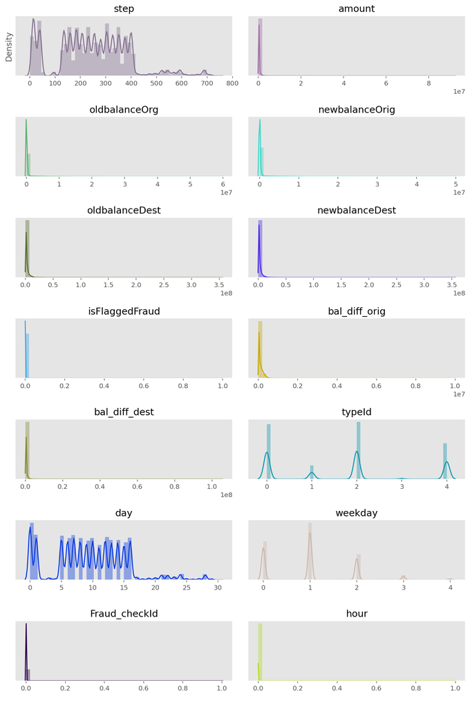

```python
fig, axes = plt.subplots(nrows = 7, ncols = 2, sharex = False, figsize=(10, 15))

colors = []
for i in range(14):
  colors.append('#%06X' % randint(0, 0xFFFFFF))

for ax, col, color in zip(axes.flat, numerical_features, colors):
  sns.distplot(a = dataset[col], bins = 50, ax = ax, color = color)
  ax.set_title(col)
  plt.setp(axes, yticks=[])
  ax.set_xlabel(' ')
  ax.grid(False)
plt.tight_layout()
plt.show()
```

##### Inference:

- All numerical features are positively skewed except step.
- step feature consists of random data.

## Percentage of Fraud Piechart

```python
labels = ['Not a Fraud','Fraud']
values = dataset.Fraud_checkId.value_counts()

fig = go.Figure(data=[go.Pie(labels=labels, values=values, hole=.3)])
fig.show()
```

[interactive chart not shown]

##### Inference:

- From the above donut chart we can see that mostly Not a fraud is 99% and only Fraud case is 0.128%.
- As it can be seen that there is high imbalance in clases.

## Percentage of Flagged fraud Pie chart

```python
labels = ['Not a Fraud','Fraud']
values = dataset.isFlaggedFraud.value_counts()

fig = go.Figure(data=[go.Pie(labels=labels, values=values, hole=.3)])
fig.show()
```

[interactive chart not shown]

##### Inference:

- From the above donut chart we can see that is Flagged mostly Not a fraud is high and there is only 16 transactions under flagged fraud which is very less.

## PieChart & Bar Chart for type transaction

```python
values = dataset.type.value_counts()
values
```

```
CASH_OUT    2237500
PAYMENT     2151495
CASH_IN     1399284
TRANSFER     532909
DEBIT         41432
Name: type, dtype: int64
```

```python
labels = ['CASH_OUT','PAYMENT', 'CASH_IN', 'TRANSFER', 'DEBIT']
values = dataset.type.value_counts()

fig = go.Figure(data=[go.Pie(labels=labels, values=values)])
fig.show()
```

[interactive chart not shown]

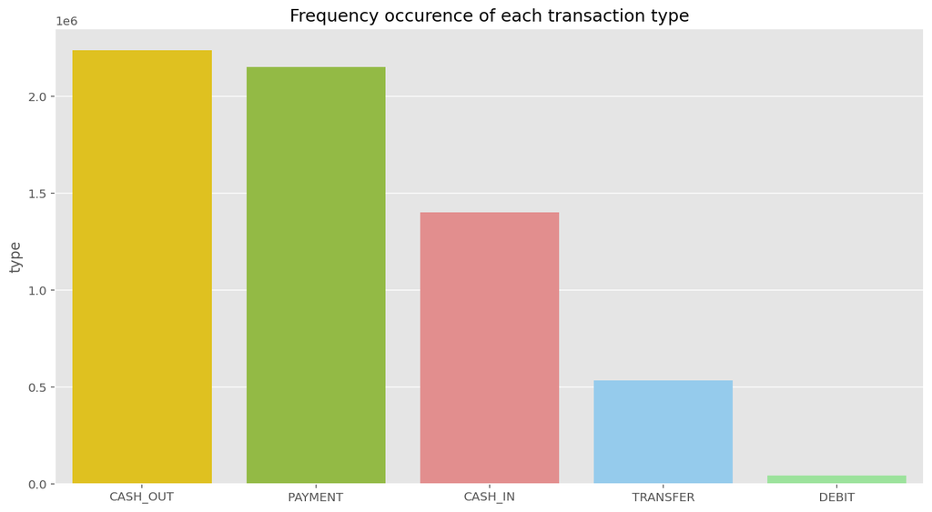

```python
colors_list = ['gold', 'yellowgreen', 'lightcoral', 'lightskyblue', 'lightgreen']
figure = plt.figure(figsize = [13, 7])

sns.barplot(dataset['type'].value_counts().index, dataset['type'].value_counts(), palette  = colors_list)
plt.title('Frequency occurence of each transaction type')
plt.show()
```

##### Inference:

- We can see that count of CASH_OUT transaction is more than any other type of transaction and that is 35.2% of all the transaction.

## Sunburst chart on amount under different transaction type and whether it is fraud or not

```python
df1= dataset.groupby(['Fraud_checkId','type']).agg(average_amt=('amount', np.mean)).reset_index()
df1.T
```

|  | 0 | 1 | 2 | 3 | 4 | 5 | 6 |
| --- | --- | --- | --- | --- | --- | --- | --- |
| Fraud_checkId | False | False | False | False | False | True | True |
| type | CASH_IN | CASH_OUT | DEBIT | PAYMENT | TRANSFER | CASH_OUT | TRANSFER |
| average_amt | 168920.242004 | 173917.205721 | 5483.665314 | 13057.60466 | 906742.512005 | 1464797.847836 | 1418862.111548 |

##### Inference:

- We can see the average amount that is transfered under each transaction type and grouping them on fraud feature.
  - Under False Fraud TRANSFER average_amt is showing the highest average.
  - Under True Fraud CASH_OUT average_amt is showing the highest average.

```python
fig = px.sunburst(dataset, path=['Fraud_checkId', 'type'], values='amount')
fig.show()
```

[interactive chart not shown]

##### Inference:

- From the above sunburst chart, we have compared the fraud with all type transaction.

```python
pd.pivot_table(dataset , index= ['isFlaggedFraud' , 'type'] ,values= 'amount').T
```

| isFlaggedFraud type | 0 CASH_IN | 0 CASH_OUT | 0 DEBIT | 0 PAYMENT | 0 TRANSFER | 1 TRANSFER |
| --- | --- | --- | --- | --- | --- | --- |
| amount | 168920.242004 | 176273.964346 | 5483.665314 | 13057.60466 | 910528.383183 | 4.861598e+06 |

##### Inference:

- We can see the average amount that is transfered under each transaction type and grouping them on is flagged fraud.

```python
fig = px.sunburst(dataset, path=['isFlaggedFraud', 'type'], values='amount')
fig.show()
```

[interactive chart not shown]

##### Inference:

- From the above sunburst chart, we have compared the isFlaggedFraud with all type transaction. In the isFlaggedFraud True we can see that TRANSFER is only there.

## Most Common amount used for transaction

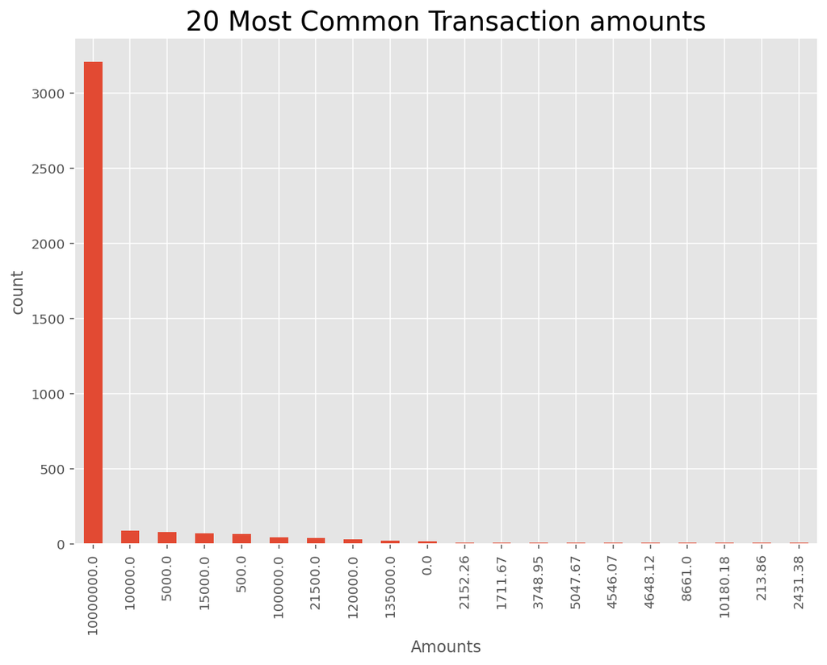

```python
plt.rcParams['figure.figsize'] = (10, 7)

dataset['amount'].value_counts().head(20).plot.bar()
plt.title('20 Most Common Transaction amounts', fontsize = 20)
plt.xlabel('Amounts')
plt.ylabel('count')
plt.show()
```

##### Inference:

- In the chart we can see the 20 most common amount used for transaction.

## Count Of Fraudulent under each type

```python
fraud_count=dataset.groupby(['Fraud_checkId', 'type']).size().reset_index().rename(columns={0:'Count of fraudlent'})
fraud_count
```

|  | Fraud_checkId | type | Count of fraudlent |
| --- | --- | --- | --- |
| 0 | False | CASH_IN | 1399284 |
| 1 | False | CASH_OUT | 2233415 |
| 2 | False | DEBIT | 41432 |
| 3 | False | PAYMENT | 2151495 |
| 4 | False | TRANSFER | 528846 |
| 5 | True | CASH_OUT | 4085 |
| 6 | True | TRANSFER | 4063 |

```python
fraud_claim_1 = fraud_count.loc[fraud_count['Fraud_checkId']==1]
```

```python
fig= px.bar(fraud_claim_1, x='Fraud_checkId', y='Count of fraudlent', color='type', barmode='group', height=400, title='Count of Fraud True')
fig.show()
```

[interactive chart not shown]

##### Inference:

- Bar chart on count of transaction when fraud is True.
  - CASH_OUT- 4085
  - TRANSFER- 4063

```python
fraud_claim_0 = fraud_count.loc[fraud_count['Fraud_checkId']==0]
fraud_claim_0
```

|  | Fraud_checkId | type | Count of fraudlent |
| --- | --- | --- | --- |
| 0 | False | CASH_IN | 1399284 |
| 1 | False | CASH_OUT | 2233415 |
| 2 | False | DEBIT | 41432 |
| 3 | False | PAYMENT | 2151495 |
| 4 | False | TRANSFER | 528846 |

```python
fig= px.bar(fraud_claim_0, x='Fraud_checkId', y='Count of fraudlent', color='type', barmode='group', height=400, title='Count of Fraud False')
fig.show()
```

[interactive chart not shown]

##### Inference:

- Bar chart on count of transaction when fraud is False.

```python
flagged_count=dataset.groupby(['isFlaggedFraud', 'type']).size().reset_index().rename(columns={0:'Count of flagged fraud'})
flagged_count
```

|  | isFlaggedFraud | type | Count of flagged fraud |
| --- | --- | --- | --- |
| 0 | 0 | CASH_IN | 1399284 |
| 1 | 0 | CASH_OUT | 2237500 |
| 2 | 0 | DEBIT | 41432 |
| 3 | 0 | PAYMENT | 2151495 |
| 4 | 0 | TRANSFER | 532893 |
| 5 | 1 | TRANSFER | 16 |

```python
flagged_claim_1 = flagged_count.loc[flagged_count['isFlaggedFraud']==1]
```

```python
fig= px.bar(flagged_claim_1, x='isFlaggedFraud', y='Count of flagged fraud', color='type', barmode='group', height=400, title='Count of Flagged Fraudlent')
fig.show()
```

[interactive chart not shown]

##### Inference:

- Under flagged Fraud only 16 transaction are recorded and that to under TRANSFER type.

```python
flagged_claim_0 = flagged_count.loc[flagged_count['isFlaggedFraud']==0]
flagged_claim_0
```

|  | isFlaggedFraud | type | Count of flagged fraud |
| --- | --- | --- | --- |
| 0 | 0 | CASH_IN | 1399284 |
| 1 | 0 | CASH_OUT | 2237500 |
| 2 | 0 | DEBIT | 41432 |
| 3 | 0 | PAYMENT | 2151495 |
| 4 | 0 | TRANSFER | 532893 |

```python
fig= px.bar(flagged_claim_0, x='isFlaggedFraud', y='Count of flagged fraud', color='type', barmode='group', height=400, title='Count of Fraudlent')
fig.show()
```

[interactive chart not shown]

##### Inference:

- Above bar chart is count of false flagged fraud transaction.

## Min Max Under Amount Features When Fraud Is True & Flagged Is True

```python
min_amt_transfer_fraud= dataset.loc[(dataset['Fraud_checkId']==1)]
```

```python
frame = min_amt_transfer_fraud[['type', 'amount']].groupby('type').mean().reset_index()
trans_amount_frame = pd.DataFrame(frame)
frame.columns = ['Transaction Type', 'Average Transacted Amount']
trans_amount_frame['Max Amt'] = min_amt_transfer_fraud[['type', 'amount']].groupby('type').agg(['max']).values
trans_amount_frame['Min Amt'] = min_amt_transfer_fraud[['type', 'amount']].groupby('type').agg(['min']).values
print('Where Fraud_checkId is True\n')
trans_amount_frame.transpose()
```

```
Where Fraud_checkId is True
```

|  | 0 | 1 |
| --- | --- | --- |
| Transaction Type | CASH_OUT | TRANSFER |
| Average Transacted Amount | 1464797.847836 | 1418862.111548 |
| Max Amt | 10000000.0 | 10000000.0 |
| Min Amt | 0.0 | 63.8 |

```python
min_amt_transfer_fraud= dataset.loc[(dataset['isFlaggedFraud']==1)]
```

```python
frame = min_amt_transfer_fraud[['type', 'amount']].groupby('type').mean().reset_index()
trans_amount_frame = pd.DataFrame(frame)
frame.columns = ['Transaction Type', 'Average Transacted Amount']
trans_amount_frame['Max Amt'] = min_amt_transfer_fraud[['type', 'amount']].groupby('type').agg(['max']).values
trans_amount_frame['Min Amt'] = min_amt_transfer_fraud[['type', 'amount']].groupby('type').agg(['min']).values
print('Where isFlaggedFraud is True\n')
trans_amount_frame.transpose()
```

```
Where isFlaggedFraud is True
```

|  | 0 |
| --- | --- |
| Transaction Type | TRANSFER |
| Average Transacted Amount | 4861597.730625 |
| Max Amt | 10000000.0 |
| Min Amt | 353874.22 |

##### Inference:

#### Min Max Under Amount Features When Fraud Is True & Flagged Is True

- From the above table we can see that Max Amt under Fraud is 10000000.0 for both transaction type(CASH_OUT,TRANSFER).
- From the above table we can see that Max Amt under Flagged Fraud is 10000000.0 for transaction type(TRANSFER) and Min Amt is 353874.22.
- This shows the average amount fraudster try to swipe out from the account, same for Min & Max. They must try to check for these.

## Checking On Receiving Customer details

```python
dataset.nameOrig.nunique()
```

```
6353307
```

```python
dataset.nameDest.nunique()
```

```
2722362
```

```python
dataset.nameDest.value_counts().head(20)
```

```
C1286084959    113
C985934102     109
C665576141     105
C2083562754    102
C248609774     101
C1590550415    101
C451111351      99
C1789550256     99
C1360767589     98
C1023714065     97
C977993101      96
C97730845       96
C392292416      95
C1899073220     92
C306206744      91
C1234776885     90
C1782113663     90
C998351292      89
C716083600      89
C909295153      88
Name: nameDest, dtype: int64
```

```python
cust_fraud=dataset[dataset['Fraud_checkId']==1].groupby(['nameDest']).size().reset_index().rename(columns={0:'Count of Transaction Under Fraud'})
cust_fraud.sort_values(by='Count of Transaction Under Fraud', ascending=False)
```

|  | nameDest | Count of Transaction Under Fraud |
| --- | --- | --- |
| 4210 | C2020337583 | 2 |
| 618 | C1148781766 | 2 |
| 5683 | C425934297 | 2 |
| 2691 | C1656842502 | 2 |
| 7974 | C967226405 | 2 |
| ... | ... | ... |
| 2706 | C1660559503 | 1 |
| 2705 | C1660535185 | 1 |
| 2704 | C1659926495 | 1 |
| 2703 | C165922010 | 1 |
| 8102 | C999955448 | 1 |

8103 rows × 2 columns

##### Inference:

- By seeing the above customer transaction count it is quite suspicious that they are doing transaction more than 100 times in a month, and while seeing it under the fraud the maximum time of occurence is 2 times.

## Checking on Amount value with Fraud_checkId

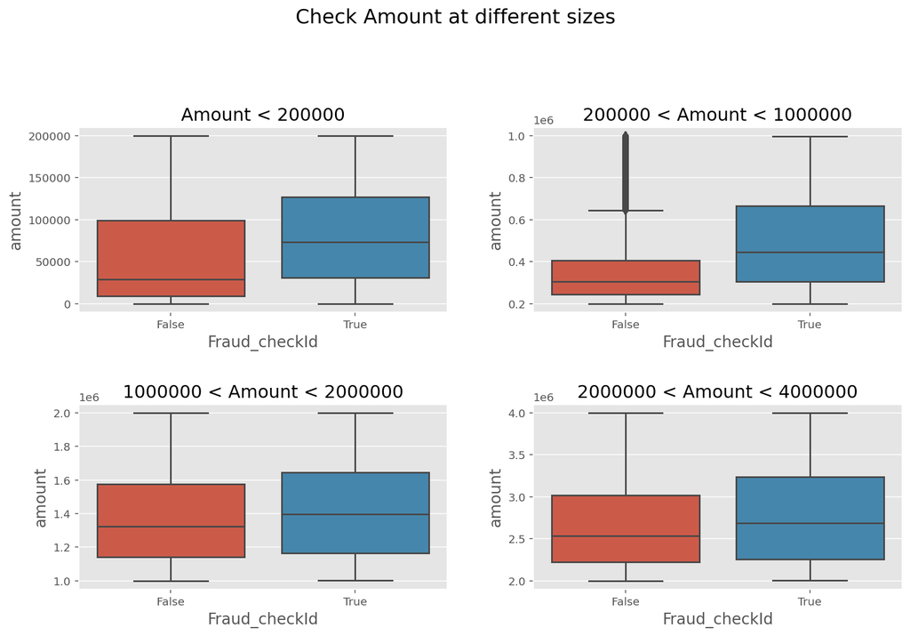

```python
figure = plt.figure(figsize = [12, 8])
plt.subplot(2, 2, 1)
sns.boxplot(x = 'Fraud_checkId', y = 'amount', data = dataset[dataset['amount'] < 200000])
plt.xlabel('Fraud_checkId', size = 14)
plt.ylabel('amount', size = 14)
plt.title('Amount < 200000', size = 16)

plt.subplot(2, 2, 2)
sns.boxplot(x = 'Fraud_checkId', y = 'amount', data = dataset[(dataset['amount'] > 200000) & (dataset['amount'] < 1000000)])
plt.xlabel('Fraud_checkId', size = 14)
plt.ylabel('amount', size = 14)
plt.title('200000 < Amount < 1000000', size = 16)

plt.subplot(2, 2, 3)
sns.boxplot(x = 'Fraud_checkId', y = 'amount', data = dataset[(dataset['amount'] > 1000000) & (dataset['amount'] < 2000000)])
plt.xlabel('Fraud_checkId', size = 14)
plt.ylabel('amount', size = 14)
plt.title('1000000 < Amount < 2000000', size = 16)

plt.subplot(2, 2, 4)
sns.boxplot(x = 'Fraud_checkId', y = 'amount', data = dataset[(dataset['amount'] > 2000000) & (dataset['amount'] < 4000000)])
plt.xlabel('Fraud_checkId', size = 14)
plt.ylabel('amount', size = 14)
plt.title('2000000 < Amount < 4000000', size = 16)

plt.suptitle('Check Amount at different sizes', size = 18, y = 1.02)
plt.tight_layout(pad = 3.0)
plt.show()
```

##### Inference:

- We can see that the median values of being fraud are high than the median values of not fraud.

## We will check isFlaggedFraud is irrelevant or not?

isFlaggedFraud-The business model aims to control massive transfers from one account to another and flags illegal attempts. An illegal attempt in this dataset is an attempt to transfer more than 200.000 in a single transaction.

it is seen that origin of isFlaggedFraud is unclear as per the description provided. There are 16 entries where the isFlaggedFraud feature is and is not seem to correlate with any explanatory variable. The data is described as isFlaggedFraud being set when an attempt is made to 'TRANSFER' an 'amount' greater than 200,000. isFlaggedFraud can remain not set despite this condition being met.

```python
dataset.groupby(['isFlaggedFraud','type']).size().reset_index().rename(columns={0:'Count of Customer Transaction'})
```

|  | isFlaggedFraud | type | Count of Customer Transaction |
| --- | --- | --- | --- |
| 0 | 0 | CASH_IN | 1399284 |
| 1 | 0 | CASH_OUT | 2237500 |
| 2 | 0 | DEBIT | 41432 |
| 3 | 0 | PAYMENT | 2151495 |
| 4 | 0 | TRANSFER | 532893 |
| 5 | 1 | TRANSFER | 16 |

```python
print('\nThe type of transactions in which isFlaggedFraud is set: \
{}'.format(list(dataset.loc[dataset.isFlaggedFraud == 1].type.drop_duplicates())))
                                                            # only 'TRANSFER'

dfTransfer = dataset.loc[dataset.type == 'TRANSFER']
dfFlagged = dataset.loc[dataset.isFlaggedFraud == 1]
dfNotFlagged = dataset.loc[dataset.isFlaggedFraud == 0]

print('\nMin amount transaction when isFlaggedFraud is set= {}'\
                                  .format(dfFlagged.amount.min()))

print('\nMax amount transaction in a TRANSFER where isFlaggedFraud is not set=\
 {}'.format(dfTransfer.loc[dfTransfer.isFlaggedFraud == 0].amount.max()))
```

```
The type of transactions in which isFlaggedFraud is set: ['TRANSFER']

Min amount transaction when isFlaggedFraud is set= 353874.22

Max amount transaction in a TRANSFER where isFlaggedFraud is not set= 92445516.64
```

```python
flagged= dataset[dataset['isFlaggedFraud'] == 1]
flagged
```

|  | step | type | amount | nameOrig | oldbalanceOrg | newbalanceOrig | nameDest | oldbalanceDest | newbalanceDest | isFlaggedFraud | ... | typeId | dest_account | day | weekday | sin_hour | cos_hour | sin_weekday | cos_weekday | Fraud_checkId | hour |
| --- | --- | --- | --- | --- | --- | --- | --- | --- | --- | --- | --- | --- | --- | --- | --- | --- | --- | --- | --- | --- | --- |
| 2736446 | 212 | TRANSFER | 4953893.08 | C728984460 | 4953893.08 | 4953893.08 | C639921569 | 0.0 | 0.0 | 1 | ... | 1 | C | 8 | 1 | 0.798636 | 0.601815 | 0.017452 | 0.999848 | False | 0 |
| 3247297 | 250 | TRANSFER | 1343002.08 | C1100582606 | 1343002.08 | 1343002.08 | C1147517658 | 0.0 | 0.0 | 1 | ... | 1 | C | 10 | 1 | 0.887011 | 0.461749 | 0.017452 | 0.999848 | False | 0 |
| 3760288 | 279 | TRANSFER | 536624.41 | C1035541766 | 536624.41 | 536624.41 | C1100697970 | 0.0 | 0.0 | 1 | ... | 1 | C | 11 | 1 | 0.938191 | 0.346117 | 0.017452 | 0.999848 | False | 0 |
| 5563713 | 387 | TRANSFER | 4892193.09 | C908544136 | 4892193.09 | 4892193.09 | C891140444 | 0.0 | 0.0 | 1 | ... | 1 | C | 16 | 2 | 0.993068 | -0.117537 | 0.034899 | 0.999391 | False | 0 |
| 5996407 | 425 | TRANSFER | 10000000.00 | C689608084 | 19585040.37 | 19585040.37 | C1392803603 | 0.0 | 0.0 | 1 | ... | 1 | C | 17 | 2 | 0.960050 | -0.279829 | 0.034899 | 0.999391 | False | 0 |
| 5996409 | 425 | TRANSFER | 9585040.37 | C452586515 | 19585040.37 | 19585040.37 | C1109166882 | 0.0 | 0.0 | 1 | ... | 1 | C | 17 | 2 | 0.960050 | -0.279829 | 0.034899 | 0.999391 | False | 0 |
| 6168499 | 554 | TRANSFER | 3576297.10 | C193696150 | 3576297.10 | 3576297.10 | C484597480 | 0.0 | 0.0 | 1 | ... | 1 | C | 23 | 3 | 0.662620 | -0.748956 | 0.052336 | 0.998630 | False | 0 |
| 6205439 | 586 | TRANSFER | 353874.22 | C1684585475 | 353874.22 | 353874.22 | C1770418982 | 0.0 | 0.0 | 1 | ... | 1 | C | 24 | 3 | 0.551937 | -0.833886 | 0.052336 | 0.998630 | False | 0 |
| 6266413 | 617 | TRANSFER | 2542664.27 | C786455622 | 2542664.27 | 2542664.27 | C661958277 | 0.0 | 0.0 | 1 | ... | 1 | C | 25 | 3 | 0.434445 | -0.900698 | 0.052336 | 0.998630 | False | 0 |
| 6281482 | 646 | TRANSFER | 10000000.00 | C19004745 | 10399045.08 | 10399045.08 | C1806199534 | 0.0 | 0.0 | 1 | ... | 1 | C | 26 | 3 | 0.317305 | -0.948324 | 0.052336 | 0.998630 | False | 0 |
| 6281484 | 646 | TRANSFER | 399045.08 | C724693370 | 10399045.08 | 10399045.08 | C1909486199 | 0.0 | 0.0 | 1 | ... | 1 | C | 26 | 3 | 0.317305 | -0.948324 | 0.052336 | 0.998630 | False | 0 |
| 6296014 | 671 | TRANSFER | 3441041.46 | C917414431 | 3441041.46 | 3441041.46 | C1082139865 | 0.0 | 0.0 | 1 | ... | 1 | C | 27 | 3 | 0.212178 | -0.977231 | 0.052336 | 0.998630 | False | 0 |
| 6351225 | 702 | TRANSFER | 3171085.59 | C1892216157 | 3171085.59 | 3171085.59 | C1308068787 | 0.0 | 0.0 | 1 | ... | 1 | C | 29 | 4 | 0.078459 | -0.996917 | 0.069756 | 0.997564 | False | 0 |
| 6362460 | 730 | TRANSFER | 10000000.00 | C2140038573 | 17316255.05 | 17316255.05 | C1395467927 | 0.0 | 0.0 | 1 | ... | 1 | C | 30 | 4 | -0.043619 | -0.999048 | 0.069756 | 0.997564 | False | 1 |
| 6362462 | 730 | TRANSFER | 7316255.05 | C1869569059 | 17316255.05 | 17316255.05 | C1861208726 | 0.0 | 0.0 | 1 | ... | 1 | C | 30 | 4 | -0.043619 | -0.999048 | 0.069756 | 0.997564 | False | 1 |
| 6362584 | 741 | TRANSFER | 5674547.89 | C992223106 | 5674547.89 | 5674547.89 | C1366804249 | 0.0 | 0.0 | 1 | ... | 1 | C | 30 | 4 | -0.091502 | -0.995805 | 0.069756 | 0.997564 | False | 1 |

16 rows × 23 columns

## Check1

We will check isFlaggedFraud is determine to oldBalanceDest or newBalanceDest. The old balance is identical to new balance for both sender and receiver where isFlaggedFraud is True. This is because the transaction is halted. oldbalanceDest=0 in every such transaction. Since isFlaggedFraud can remain not set in TRANSFERS where oldBalanceDest and newBalanceDest can both be 0, these conditions do not determine the state of isFlaggedFraud.

```python
print('\nThe number of TRANSFERs where isFlaggedFraud = 0, yet oldBalanceDest = 0 and\
 newBalanceDest = 0: {}'.\
format(len(dfTransfer.loc[(dfTransfer.isFlaggedFraud == 0) & \
(dfTransfer.oldbalanceDest == 0) & (dfTransfer.newbalanceDest == 0)])))
```

```
The number of TRANSFERs where isFlaggedFraud = 0, yet oldBalanceDest = 0 and newBalanceDest = 0: 4158
```

## Check2

Now, we will check isFlaggedFraud is determine on oldBalanceOrig since the corresponding range of values overlaps with that for TRANSFERs where isFlaggedFraud is not set. We will check as per the condition we have derive above that old balance is identical to new balance for both sender and receiver where isFlaggedFraud is True. And this condition is not clear as per the result we get.

```python
print('\nMin, Max of oldBalanceOrig for isFlaggedFraud = 1 TRANSFERs: {}'.format([round(dfFlagged.oldbalanceOrg.min()), round(dfFlagged.oldbalanceOrg.max())]))

print('\nMin, Max of oldBalanceOrig for isFlaggedFraud = 0 TRANSFERs where oldBalanceOrig = newBalanceOrig: {}'.format([dfTransfer.loc[(dfTransfer.isFlaggedFraud == 0) & (dfTransfer.oldbalanceOrg \
== dfTransfer.newbalanceOrig)].oldbalanceOrg.min(), round(dfTransfer.loc[(dfTransfer.isFlaggedFraud == 0) & (dfTransfer.oldbalanceOrg == dfTransfer.newbalanceOrig)].oldbalanceOrg.max())]))
```

```
Min, Max of oldBalanceOrig for isFlaggedFraud = 1 TRANSFERs: [353874, 19585040]

Min, Max of oldBalanceOrig for isFlaggedFraud = 0 TRANSFERs where oldBalanceOrig = newBalanceOrig: [0.0, 575668]
```

## Saving Dataframe For Further Processing of Data Modeling

```python
dataset_copy= dataset.copy()
```

```python
dataset_copy
```

|  | step | type | amount | nameOrig | oldbalanceOrg | newbalanceOrig | nameDest | oldbalanceDest | newbalanceDest | isFlaggedFraud | ... | typeId | dest_account | day | weekday | sin_hour | cos_hour | sin_weekday | cos_weekday | Fraud_checkId | hour |
| --- | --- | --- | --- | --- | --- | --- | --- | --- | --- | --- | --- | --- | --- | --- | --- | --- | --- | --- | --- | --- | --- |
| 0 | 1 | PAYMENT | 9839.64 | C1231006815 | 170136.00 | 160296.36 | M1979787155 | 0.00 | 0.00 | 0 | ... | 0 | M | 0 | 0 | 0.004363 | 0.999990 | 0.000000 | 1.000000 | False | 0 |
| 1 | 1 | PAYMENT | 1864.28 | C1666544295 | 21249.00 | 19384.72 | M2044282225 | 0.00 | 0.00 | 0 | ... | 0 | M | 0 | 0 | 0.004363 | 0.999990 | 0.000000 | 1.000000 | False | 0 |
| 2 | 1 | TRANSFER | 181.00 | C1305486145 | 181.00 | 0.00 | C553264065 | 0.00 | 0.00 | 0 | ... | 1 | C | 0 | 0 | 0.004363 | 0.999990 | 0.000000 | 1.000000 | True | 0 |
| 3 | 1 | CASH_OUT | 181.00 | C840083671 | 181.00 | 0.00 | C38997010 | 21182.00 | 0.00 | 0 | ... | 2 | C | 0 | 0 | 0.004363 | 0.999990 | 0.000000 | 1.000000 | True | 0 |
| 4 | 1 | PAYMENT | 11668.14 | C2048537720 | 41554.00 | 29885.86 | M1230701703 | 0.00 | 0.00 | 0 | ... | 0 | M | 0 | 0 | 0.004363 | 0.999990 | 0.000000 | 1.000000 | False | 0 |
| ... | ... | ... | ... | ... | ... | ... | ... | ... | ... | ... | ... | ... | ... | ... | ... | ... | ... | ... | ... | ... | ... |
| 6362615 | 743 | CASH_OUT | 339682.13 | C786484425 | 339682.13 | 0.00 | C776919290 | 0.00 | 339682.13 | 0 | ... | 2 | C | 30 | 4 | -0.100188 | -0.994969 | 0.069756 | 0.997564 | True | 1 |
| 6362616 | 743 | TRANSFER | 6311409.28 | C1529008245 | 6311409.28 | 0.00 | C1881841831 | 0.00 | 0.00 | 0 | ... | 1 | C | 30 | 4 | -0.100188 | -0.994969 | 0.069756 | 0.997564 | True | 1 |
| 6362617 | 743 | CASH_OUT | 6311409.28 | C1162922333 | 6311409.28 | 0.00 | C1365125890 | 68488.84 | 6379898.11 | 0 | ... | 2 | C | 30 | 4 | -0.100188 | -0.994969 | 0.069756 | 0.997564 | True | 1 |
| 6362618 | 743 | TRANSFER | 850002.52 | C1685995037 | 850002.52 | 0.00 | C2080388513 | 0.00 | 0.00 | 0 | ... | 1 | C | 30 | 4 | -0.100188 | -0.994969 | 0.069756 | 0.997564 | True | 1 |
| 6362619 | 743 | CASH_OUT | 850002.52 | C1280323807 | 850002.52 | 0.00 | C873221189 | 6510099.11 | 7360101.63 | 0 | ... | 2 | C | 30 | 4 | -0.100188 | -0.994969 | 0.069756 | 0.997564 | True | 1 |

6362620 rows × 23 columns

```python
dataset_copy.columns
```

```
Index(['step', 'type', 'amount', 'nameOrig', 'oldbalanceOrg', 'newbalanceOrig',
       'nameDest', 'oldbalanceDest', 'newbalanceDest', 'isFlaggedFraud',
       'Fraud_check', 'bal_diff_orig', 'bal_diff_dest', 'typeId',
       'dest_account', 'day', 'weekday', 'sin_hour', 'cos_hour', 'sin_weekday',
       'cos_weekday', 'Fraud_checkId', 'hour'],
      dtype='object')
```

```python
# Create a new pandas dataframe "category", which only has unique Categories, also sorting this list in order of CategoryId values
category = dataset_copy[['type', 'typeId']].drop_duplicates().sort_values('typeId')
category
```

|  | type | typeId |
| --- | --- | --- |
| 0 | PAYMENT | 0 |
| 2 | TRANSFER | 1 |
| 3 | CASH_OUT | 2 |
| 9 | DEBIT | 3 |
| 389 | CASH_IN | 4 |

```python
# Create a new pandas dataframe "category", which only has unique Categories, also sorting this list in order of CategoryId values
category1 = dataset_copy[['Fraud_check', 'Fraud_checkId']].drop_duplicates().sort_values('Fraud_checkId')
category1
```

|  | Fraud_check | Fraud_checkId |
| --- | --- | --- |
| 0 | Not_Fraud | False |
| 2 | Fraud | True |

```python
# Removing irrelevant columns
dataset_copy.drop(['type','nameOrig','nameDest','isFlaggedFraud','Fraud_check','dest_account',], axis=1, inplace=True)
```

```python
# saving the dataframe
dataset_copy.to_csv('new_fraud_dataframe_modeling.csv')
```

## Feature Importance

```python
def plot_variable_importance( X , y ):
    tree = DecisionTreeRegressor( random_state = 99 )
    tree.fit( X , y )
    plot_model_var_imp( tree , X , y )

def plot_model_var_imp( model , X , y ):
    imp = pd.DataFrame(
        model.feature_importances_  ,
        columns = [ 'Importance' ] ,
        index = X.columns
    )
    imp = imp.sort_values( [ 'Importance' ] , ascending = True )
    imp[ : 10 ].plot( kind = 'barh' )
    print (model.score( X , y ))
```

```python
X= dataset_copy.drop(['Fraud_checkId'], axis=1)
y= dataset['Fraud_checkId']
```

```
1.0
```

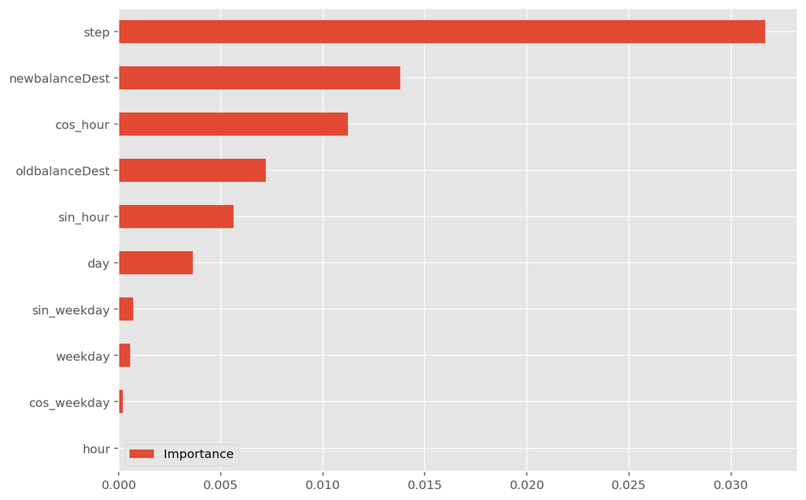

```python
plot_variable_importance(X, y)
```

### With this our Part 1 is ended next we will work on modeling.